# Polysubstance and tr. completion (post review)

Analyze the association between polysubstance at admission and tr. compleiton longitudinally along treatments, accounting for irregular observations. Answer to the reviewer’s comments.

Author

Andrés González Santa Cruz

Published

January 31, 2026

# Data Loading and Exploration

## Loading Packages and uniting databases

Proceed to load the necessary packages.

```r
# invisible("Only run from Ubuntu")
# if (!(Sys.getenv("RSTUDIO_SESSION_TYPE") == "server" || file.exists("/.dockerenv"))) {
#   if(Sys.info()["sysname"]!="Windows"){
#     Sys.setenv(RETICULATE_PYTHON = "/home/fondecytacc/.pyenv/versions/3.11.5/bin/python")
#   }
# }

#clean enviroment
rm(list = ls()); gc()

time_before_dedup3<-Sys.time()

#:#:#:#:#:#:#:#:#:#:#:#:#:#:#:#:#:#:#:#:#:#:#:#:#:#:#:#:#:#:#:#:#:#:#:#:#:#:#:#
#:#:#:#:#:#:#:#:#:#:#:#:#:#:#:#:#:#:#:#:#:#:#:#:#:#:#:#:#:#:#:#:#:#:#:#:
# --- Bootstrap reticulate con ruta relativa a getwd() ---
suppressPackageStartupMessages(library(reticulate))

# Busca .mamba_root/envs/py311/python.exe desde getwd() hacia padres
find_python_rel <- function(start = getwd(),
                            rel = file.path(".mamba_root","envs","py311","python.exe")) {
  cur <- normalizePath(start, winslash = "/", mustWork = FALSE)
  repeat {
    cand <- normalizePath(file.path(cur, rel), winslash = "/", mustWork = FALSE)
    if (file.exists(cand)) return(cand)
    parent <- dirname(cur)
    if (identical(parent, cur)) return(NA_character_)  # llegó a la raíz
    cur <- parent
  }
}

py <- find_python_rel()

if (is.na(py)) {
  stop("No se encontró Python relativo a getwd() (buscando '.mamba_root/envs/py311/python.exe').\n",
       "Directorio actual: ", getwd())
}

# Forzar ese intérprete
Sys.unsetenv(c("RETICULATE_CONDAENV","RETICULATE_PYTHON_FALLBACK"))
Sys.setenv(RETICULATE_PYTHON = py)
reticulate::use_python(py, required=T)

py_config()  # verificación

#_#_#_#_#_#_#_#_#_#_#_#_#_#_#_#_#_#_#_#_#_#_#_#_#_#_#_#_#_#_#_#_#_#_#_#_
#_#_#_#_#_#_#_#_#_#_#_#_#_#_#_#_#_#_#_#_#_#_#_#_#_#_#_#_#_#_#_#_#_#_#_#_


gc()
if(grepl("SISTRAT 2023",getwd())){
  wdpath<-
    paste0(gsub("/cons","",gsub("cons","",paste0(getwd(),"/cons"))))
} else {
  wdpath<-
    paste0(paste0(gsub("/SISTRAT 2022 \\(github\\)/_proposal_grant/2023","",getwd())),"/SISTRAT 2023/")
}

load(paste0(wdpath,
  "data/20241015_out/psu/psu_ndp_2025_10_02.Rdata"))
```

```
          used (Mb) gc trigger (Mb) max used (Mb)
Ncells  602515 32.2    1293604 69.1  1024990 54.8
Vcells 1163455  8.9    8388608 64.0  1876395 14.4
python:         G:/My Drive/Alvacast/SISTRAT 2023/.mamba_root/envs/py311/python.exe
libpython:      G:/My Drive/Alvacast/SISTRAT 2023/.mamba_root/envs/py311/python311.dll
pythonhome:     G:/My Drive/Alvacast/SISTRAT 2023/.mamba_root/envs/py311
version:        3.11.5 | packaged by conda-forge | (main, Aug 27 2023, 03:23:48) [MSC v.1936 64 bit (AMD64)]
Architecture:   64bit
numpy:           [NOT FOUND]

NOTE: Python version was forced by RETICULATE_PYTHON
          used (Mb) gc trigger  (Mb) max used  (Mb)
Ncells 1735764 92.7    2721364 145.4  2721364 145.4
Vcells 3114017 23.8    8388608  64.0  5092919  38.9
```

```r
#https://github.com/rstudio/renv/issues/544
#renv falls back to copying rather than symlinking, which is evidently very slow in this configuration.
renv::settings$use.cache(FALSE)

#only use explicit dependencies (in DESCRIPTION)
renv::settings$snapshot.type("implicit")

#check if rstools is installed
try(installr::install.Rtools(check_r_update=F))
check_quarto_version <- function(required = "1.7.29", comparator = c("ge","gt","le","lt","eq")) {
  comparator <- match.arg(comparator)
  current <- package_version(paste(unlist(quarto::quarto_version()), collapse = "."))
  req     <- package_version(required)

  ok <- switch(comparator,
               ge = current >= req,
               gt = current >  req,
               le = current <= req,
               lt = current <  req,
               eq = current == req)

  if (!ok) {
    stop(sprintf("Quarto version check failed: need %s %s (installed: %s).",
                 comparator, required, current), call. = FALSE)
  }
  invisible(TRUE)
}

check_quarto_version("1.7.29", "ge")

#change repository to CL
options(repos = c(CRAN = "https://cran.dcc.uchile.cl/"))


unlink("*_cache", recursive=T)

if(!require(pacman)){install.packages("pacman");require(pacman)}
if(!require(pak)){install.packages("pak");require(pak)}
if(!require(UpSetR)){install.packages("UpSetR");require(UpSetR)}
# Base R way: explicitly reference the pipe
`%>%` <- magrittr::`%>%`

pacman::p_unlock(lib.loc = .libPaths()) #para no tener problemas reinstalando paquetes
```

```
No 00LOCK detected in:
 C:/Users/andre/AppData/Local/R/win-library/4.4
No 00LOCK detected in:
 C:/Program Files/R/R-4.4.1/library
```

```r
if(Sys.info()["sysname"]=="Windows"){
if (getRversion() != "4.4.1") { stop("Requires R version 4.4.1; Actual: ", getRversion()) }
}

#_#_#_#_#_#_#_#_#_#_#_#_#_#_#_#_#_#_#_#_#_#_#_#_#_#_#_#_#_#_#_#_#_#_#_#_#_#_#_#
#HELPERS######################################################################
#_#_#_#_#_#_#_#_#_#_#_#_#_#_#_#_#_#_#_#_#_#_#_#_#_#_#_#_#_#_#_#_#_#_#_#_#_#_#_#

as.data.frame.TableOne <- function(x, ...) {
  capture.output(print(x, showAllLevels = TRUE, varLabels = T,...) -> x)
  y <- as.data.frame(x)
  y$characteristic <- dplyr::na_if(rownames(x), "")
  y <- y|>
    tidyr::fill(characteristic, .direction = "down")|>
    dplyr::select(characteristic, everything())
  rownames(y) <- NULL
  y}


tidy_iiw_by_plan <- function(models_by_plan,
                             conf.level = 0.95,
                             digits = 3,
                             drop_cluster = TRUE,
                             sort = c("none","plan_term"),
                             return_tidytable = FALSE) {
  sort <- match.arg(sort)

  # preserve the incoming order of plan types
  plan_levels <- names(models_by_plan) %||% seq_along(models_by_plan)

  out <- purrr::imap_dfr(models_by_plan, function(x, plan_lbl) {
    fit <- if (!is.null(x$m)) x$m else x

    tbl <- broom::tidy(fit, exponentiate = TRUE, conf.int = TRUE,
                       conf.level = conf.level)

    if (drop_cluster) {
      tbl <- dplyr::filter(tbl, !grepl("cluster\\(", term))
    }

    # keep broom's original row order
        tbl <- tbl %>%
          dplyr::mutate(
            .term_order = dplyr::row_number(),
            plan_type   = plan_lbl,
            HR          = round(estimate, digits),
            CI_low      = round(conf.low, digits),
            CI_high     = round(conf.high, digits),
            CI95 = sprintf( paste0("%.", digits, "f (%.", digits, "f, %.", digits, "f)"), as.numeric(HR), as.numeric(CI_low), as.numeric(CI_high) ),
            p           = sprintf("%1.4f", signif(p.value, 3)),
          ) %>%
          dplyr::select(plan_type, .term_order, term, CI95, p)

  })

  # optional sorting
  if (sort == "plan_term") {
    out <- out %>%
      dplyr::mutate(plan_type = factor(plan_type, levels = plan_levels)) %>%
      dplyr::arrange(plan_type, .term_order)
  } else {
    # no reordering: keep original list order & term order
    out <- out %>%
      dplyr::mutate(plan_type = factor(plan_type, levels = plan_levels)) %>%
      dplyr::arrange(as.integer(plan_type), .term_order)
  }

  out <- out %>% tidytable::select(-.term_order)

  if (return_tidytable) {
    out <- tidytable::as_tidytable(as.data.frame(out))  # robust conversion
  }

  out
}
```

[output not shown]

## Upset plot

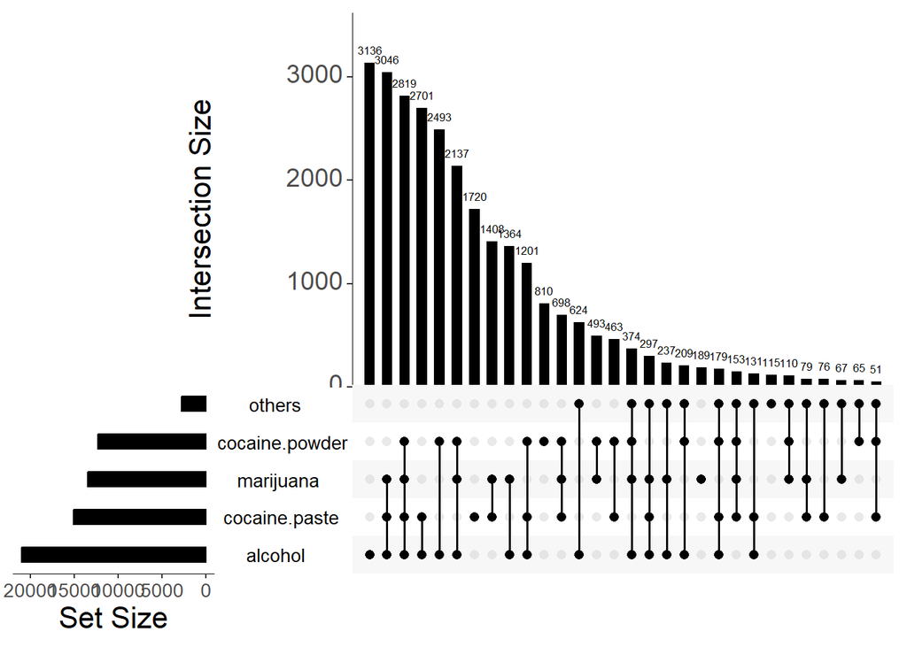

```r
# 2. assume your data.frame is called `df`
#    with columns: hash_key, otras_sus1_mod, otras_sus2_mod, otras_sus3_mod

# 3. pivot to long (one row per participant–substance), drop NAs
df_long <- dat_with_weights_stab_cons |>
  tidytable::arrange(hash_key, adm_age_rec3) |>
  tidytable::slice_head(n = 1, .by = hash_key) |>
  dplyr::mutate(
    susprindum = dplyr::case_when(
      susprindum_mar == 1 ~ "Marijuana",
      susprindum_oh  == 1 ~ "Alcohol",
      susprindum_pbc == 1 ~ "Cocaine paste",
      susprindum_coc == 1 ~ "Cocaine hydrochloride",
      susprindum_oth == 1 ~ "Other",
      TRUE               ~ NA_character_
    )
  ) |>
  dplyr::select(
    hash_key,
    primary_sub,
    second_sub1,
    second_sub2,
    second_sub3
  ) |>
  dplyr::mutate_at(
    c(
      "primary_sub",
      "second_sub1",
      "second_sub2",
      "second_sub3"
    ),
    ~ dplyr::if_else(
      . %in% c(
        "dissociatives",
        "hallucinogens",
        "inhalants",
        "amphetamine-type stimulants",
        "opioids",
        "tranquilizers/hypnotics",
        "sin sustancia principal (cip-crc)",
        "others"
      ),
      "others",
      .
    )
  ) |>
  tidyr::pivot_longer(
    cols = -hash_key,
    names_to = "which_other",
    values_to = "substance",
    values_drop_na = TRUE
  )

# 4. make an incidence (wide) matrix of 0/1
df_incidence <- df_long %>%
  dplyr::distinct(hash_key, substance) %>%      # one row per use
  dplyr::mutate(present = 1) %>%
  tidyr::pivot_wider(
    names_from   = substance,
    values_from  = present,
    values_fill  = list(present = 0)
  )

df_upset <- df_incidence %>%
  dplyr::select(-hash_key) %>%            # remove the ID column
  as.data.frame()                  # coerce tibble → base data.frame

names(df_upset) <- make.names(names(df_upset))


# 5. run upset()
library(UpSetR)
upset(
  df_upset,
  sets        = names(df_upset), # all columns
  order.by    = "freq",
  mb.ratio    = c(0.6, 0.4),
  main.bar.color = "black",
  sets.bar.color = "black",
  matrix.color   = "black",
  text.scale     = c(2, 2, 2, 1.5, 1.5, 1)
)
```

```r
png("my_upset_plot_26.png", width = 10, height = 6, units = "in", res = 600)
upset(
  df_upset,
  sets        = names(df_upset), # all columns
  order.by    = "freq",
  mb.ratio    = c(0.6, 0.4),
  main.bar.color = "black",
  sets.bar.color = "black",
  matrix.color   = "black",
  text.scale     = c(2, 2, 2, 1.5, 1.5, 1)
)
dev.off()
```

## Sens 2: One tr or more

```r
# database cons, one tr or more -------------------------------------------


as.data.frame.TableOne <- function(x, ...) {
  capture.output(print(x, showAllLevels = TRUE, varLabels = T,...) -> x)
  y <- as.data.frame(x)
  y$characteristic <- dplyr::na_if(rownames(x), "")
  y <- y|>
    tidyr::fill(characteristic, .direction = "down")|>
    dplyr::select(characteristic, everything())
  rownames(y) <- NULL
  y}


cat("After discarding Any treatment w/ death or ongoing tr")
length(unique(SISTRAT_clean_drop_patient$hash_key))
#[1] 118594

##_#_#_#_#_#_#_#_#_#_#_#_#
## TableOne (polysubstance strata) — tidy + applied to SISTRAT_clean_drop_patient
##_#_#_#_#_#_#_#_#_#_#_#_#


df <- SISTRAT_clean_drop_patient

# 1) Pick strata variable automatically
strata_var <- if ("polysubstance_strict" %in% names(df)) "polysubstance_strict" else "polysubstance"

# 2) Variables of interest
vars_interest <- c(
  "tr_noncompletion",
  "biopsych_comp_severe",
  "treat_lt_90",
  "treat_log_days",
  "adm_age_rec3",
  "year_decimal",
  "sus_ini_mod_mvv",
  "dg_psiq_cie_10_dg",
  "dg_psiq_cie_10_instudy",
  "prim_sub_daily",
  "occupation_condition_corr24",
  "primary_sub_mod"
)

# 3) Which of those should be treated as categorical
factorVars_interest <- c(
  "biopsych_comp_severe",
  "sus_ini_mod_mvv",
  "dg_psiq_cie_10_dg",
  "dg_psiq_cie_10_instudy",
  "prim_sub_daily",
  "occupation_condition_corr24",
  "primary_sub_mod",
  "tr_noncompletion",
  "treat_lt_90"
)

# 4) Labels (stored as attributes in the data; CreateTableOne doesn’t consume them directly)
attr(df$tr_noncompletion,           "label") <- "Non-completion status of treatment (Dropout / Misspelled)"
attr(df$biopsych_comp_severe,       "label") <- "Biopsychosocial compromise (Severe)"
attr(df$treat_lt_90,                "label") <- "Treatment duration (binary) (<90 days)"
attr(df$treat_log_days,             "label") <- "Treatment duration (log-scaled days)"
attr(df$adm_age_rec3,               "label") <- "Age at admission to treatment"
attr(df$year_decimal,               "label") <- "Birth year"
attr(df$sus_ini_mod_mvv,            "label") <- "Primary substance (initial diagnosis)"
attr(df$dg_psiq_cie_10_instudy,     "label") <- "Psychiatric comorbidity (ICD-10): In study"
attr(df$dg_psiq_cie_10_dg,          "label") <- "Psychiatric comorbidity (ICD-10): Diagnosis"
attr(df$prim_sub_daily,             "label") <- "Daily frequency of primary substance used at admission"
attr(df$occupation_condition_corr24,"label") <- "Occupational Status"
attr(df$primary_sub_mod,            "label") <- "Primary substance at admission to treatment"

# 5) Build analysis frame (NO slice_head; keep one row per hash_key if needed)
vars_needed <- unique(c(vars_interest, strata_var))

data_tbone <- df |>
  tidytable::select(tidytable::all_of(vars_needed)) |>
  (\(x) if ("hash_key" %in% names(x)) tidytable::distinct(x, hash_key, .keep_all = TRUE) else x)()

# 6) Create TableOne
tbone_interest <- tableone::CreateTableOne(
  vars         = vars_interest,
  data         = data_tbone,
  factorVars = factorVars_interest,
  strata     = strata_var,
  addOverall = TRUE,
  includeNA  = TRUE,
  smd        = TRUE,
  test       = TRUE
)

# 7) Export as data.frame
df_tbone <- as.data.frame.TableOne(
  tbone_interest,
  nonnormal = c("adm_age_rec3", "year_decimal", "treat_log_days"),
  smd        = TRUE
)

# 8) Desired order (characteristic + level)
order_df <- tibble::tribble(
  ~characteristic, ~level,
  "n", "",
  "Non-completion status of treatment (Dropout / Misspelled) (%)", "0",
  "Non-completion status of treatment (Dropout / Misspelled) (%)", "1",
  "Biopsychosocial compromise (Severe) (%)", "0",
  "Biopsychosocial compromise (Severe) (%)", "1",
  "Biopsychosocial compromise (Severe) (%)", NA,
  "Treatment duration (binary) (<90 days) (%)", "0",
  "Treatment duration (binary) (<90 days) (%)", "1",
  "Treatment duration (log-scaled days) (median [IQR])", "",
  "Age at admission to treatment (median [IQR])", "",
  "Birth year (median [IQR])", "",
  "Primary substance (initial diagnosis) (%)", "cocaine powder",
  "Primary substance (initial diagnosis) (%)", "cocaine paste",
  "Primary substance (initial diagnosis) (%)", "marijuana",
  "Primary substance (initial diagnosis) (%)", "alcohol",
  "Primary substance (initial diagnosis) (%)", "others",
  "Primary substance (initial diagnosis) (%)", NA,
  "Psychiatric comorbidity (ICD-10): In study (%)", "TRUE",
  "Psychiatric comorbidity (ICD-10): In study (%)", "FALSE",
  "Psychiatric comorbidity (ICD-10): Diagnosis (%)", "TRUE",
  "Daily frequency of primary substance used at admission (%)", "0",
  "Daily frequency of primary substance used at admission (%)", "1",
  "Daily frequency of primary substance used at admission (%)", NA,
  "Occupational Status (%)", "inactive",
  "Occupational Status (%)", "unemployed",
  "Occupational Status (%)", "employed",
  "Primary substance at admission to treatment (%)", "cocaine powder",
  "Primary substance at admission to treatment (%)", "cocaine paste",
  "Primary substance at admission to treatment (%)", "marijuana",
  "Primary substance at admission to treatment (%)", "alcohol",
  "Primary substance at admission to treatment (%)", "others"
) |>
  tidytable::mutate(order_id = dplyr::row_number())

# 9) Join order + arrange (keep only rows that exist in order_df; drop the helper column)
df_tbone_ordered <- df_tbone |>
  tidytable::left_join(order_df, by = c("characteristic", "level")) |>
  tidytable::arrange(order_id) |>
  tidytable::select(-order_id)

# df_tbone_ordered is your final ordered table

head(df_tbone_ordered)
```

```
After discarding Any treatment w/ death or ongoing tr[1] 118594
# A tidytable: 6 × 8
  characteristic                     level Overall `0`   `1`   p     test  SMD
  <chr>                              <chr> <chr>   <chr> <chr> <chr> <chr> <chr>
1 n                                  ""    " 1591… "  4… " 11… ""    ""    ""
2 Non-completion status of treatmen… "0"   "  447… "  1… "  2… "<0.… ""    " 0.…
3 Non-completion status of treatmen… "1"   " 1143… "  2… "  8… ""    ""    ""
4 Biopsychosocial compromise (Sever… "0"   " 1049… "  3… "  7… "<0.… ""    " 0.…
5 Biopsychosocial compromise (Sever… "1"   "  521… "  1… "  4… ""    ""    ""
6 Biopsychosocial compromise (Sever… <NA>  "   19… "   … "   … ""    ""    ""
```

### Imputation

This script selects which variables to impute, builds a multivariate formula to impute them using random forest + PMM, runs missRanger on a safe subset, then merges back only the imputed columns into the full dataset, and finally displays an OOB summary of the error by variable.

```r
set.seed(2125)

# Keep only variables that actually exist to avoid errors
vars_impute <- intersect(vars_impute, names(df))
if (length(vars_impute) == 0) stop("None of the vars in vars_interest/polysubstance_strict/plan_type_mod exist in the data.")

#_#_#_#_#_#_#_#_#_#_#_#_#_#_#_#_
# 1) Predictors (you can expand/trim this list as you prefer)
#    Tip: include easy, generally-available covariates to make MAR more plausible
#_#_#_#_#_#_#_#_#_#_#_#_#_#_#_#_
predictor_pool <- c(
  # strong helpers already in your dataset
  "adm_age_rec3", "year_decimal", "treat_log_days", "treat_lt_90",
  "biopsych_comp_severe", "tr_noncompletion", "prim_sub_daily",
  "primary_sub_mod", "occupation_condition_corr24",
  "pub_center", "type_center", "episodes",
  "sex_rec", "plan_type_mod", "primary_sub_std", "tr_completion",
  "dg_psiq_cie_10_dg", "dg_psiq_cie_10_instudy",
  "episodes", "age_subs_onset_rec2", "age_primary_onset_rec2",
  "tenure_status_household", "macrozone_center", "adm_motive",
  "marital_status", "ed_attainment", "sub_dep_icd10_status", "pub_center", "senda", "num_trat_ant",
  "fecha_ultimo_tratamiento"
)

# Use only columns that exist
predictor_pool <- intersect(unique(c(predictor_pool, vars_impute)), names(df))

# Make sure we still have something on the RHS
if (length(predictor_pool) == 0) stop("No predictors found in the data. Please add some predictor names that exist.")

#_#_#_#_#_#_#_#_#_#_#_#_#_#_#_#_
# 2) Build formula: (targets) ~ (predictors)
#    missRanger will impute ONLY the LHS variables
#_#_#_#_#_#_#_#_#_#_#_#_#_#_#_#_
lhs <- paste(vars_impute, collapse = " + ")
rhs <- paste(predictor_pool, collapse = " + ")
form_miss <- as.formula(paste(lhs, "~", rhs))

#_#_#_#_#_#_#_#_#_#_#_#_#_#_#_#_
# 3) Arrange for reproducibility and run missRanger
#_#_#_#_#_#_#_#_#_#_#_#_#_#_#_#_
post_df_ord <- dplyr::arrange(df, hash_key, adm_date_num_rec2)

# columns to pass to missRanger = targets (impute) + predictors
post_cols_mr <- unique(c(vars_impute, predictor_pool))

# subset safely whether dat_ord is data.table/tidytable or data.frame
if (inherits(post_df_ord, "data.table")) {
  post_df_sub <- post_df_ord[, ..post_cols_mr]
} else {
  # fallback for data.frame / tibble
  post_df_sub <- post_df_ord[, post_cols_mr, drop = FALSE]
}

# (optional) force to plain data.frame to avoid method dispatch surprises
post_df_sub <- as.data.frame(post_df_sub)

post_SISTRAT_imputed_only <- missRanger::missRanger(
  data      = post_df_sub,         # << use the safe subset
  formula   = form_miss,        # ONLY LHS vars in vars_impute will be imputed
  num.trees = 100,
  pmm.k     = 5,
  maxiter   = 50,
  returnOOB = TRUE,
  verbose   = 2,
  seed      = 2125
)
```

```
Missing value imputation by random forests
```

```r
#_#_#_#_#_#_#_#_#_#_#_#_#_#_#_#_
# 4) Write imputed values back to your full data
#_#_#_#_#_#_#_#_#_#_#_#_#_#_#_#_
# Make safe copies as data.frame
post_SISTRAT_clean_drop_patient_multiple_imp <- as.data.frame(post_df_ord)
post_SISTRAT_imputed_only_df <- as.data.frame(post_SISTRAT_imputed_only)

# Regular data.frame column replacement works with a character vector of names
post_SISTRAT_clean_drop_patient_multiple_imp[vars_impute] <- post_SISTRAT_imputed_only_df[vars_impute]

#_#_#_#_#_#_#_#_#_#_#_#_#_#_#_#_
# 5) OOB error summary → kable
#    (missRanger stores per-target OOB error in the "oob" attribute)
#_#_#_#_#_#_#_#_#_#_#_#_#_#_#_#_
post_oob_vec <- attr(post_SISTRAT_imputed_only, "oob")
if (!is.null(post_oob_vec)) {
  post_df_oob <- data.frame(
    Variable = names(post_oob_vec),
    OOB_Error = round(as.numeric(post_oob_vec),3)
  )
  post_df_oob <- post_df_oob[order(post_df_oob$Variable), , drop = FALSE]
  knitr::kable(post_df_oob, format = "markdown", align = c("l","r"),
               col.names = c("Variable", "OOB error (1 - R² or class error)"))
} else {
  message("No OOB error attribute returned by missRanger.")
}
# |  |Variable              | OOB error (1 - R² or class error)|
# |:--|:--------------------|---------------------------------:|
# |3  |biopsych_comp_severe |                             0.779|
# |1  |prim_sub_daily       |                             0.839|
# |2  |sus_ini_mod_mvv      |                             0.344|

# post_oob_vec
# treat_lt_90        treat_log_days        prim_sub_daily biopsych_comp_severe       sus_ini_mod_mvv
# 0.0008214128          0.3522101134          0.8405593966          0.7624347156          0.3418216406

saveRDS(
  post_SISTRAT_clean_drop_patient_multiple_imp,
  file = file.path(wdpath, "data/20241015_out/psu", "post_SISTRAT_clean_drop_patient_multiple_imp.rds")
)
# post_SISTRAT_clean_drop_patient_multiple_imp <-
#   readRDS(file.path(wdpath, "data/20241015_out/psu", "post_SISTRAT_clean_drop_patient_multiple_imp.rds"))
```

[output not shown]

|  | Variable | OOB error (1 - R² or class error) |
| --- | --- | --- |
| 4 | biopsych_comp_severe | 0.762 |
| 3 | prim_sub_daily | 0.841 |
| 5 | sus_ini_mod_mvv | 0.342 |
| 2 | treat_log_days | 0.352 |
| 1 | treat_lt_90 | 0.001 |

### Survival prep

```r
# Censor date you specified
censor_date <- as.Date("2025-05-28")

post_SISTRAT_traj <-
  post_SISTRAT_clean_drop_patient_multiple_imp|>
  tidytable::ungroup()|>
  # Canonical ordering within each patient
  tidytable::arrange(hash_key, adm_date_rec2, disch_date_rec6)|>
  tidytable::group_by(hash_key)|>
  # Treatment sequence and entry date
  tidytable::mutate(
    treatment     = tidytable::row_number(),
    is_first_occurrence = tidytable::if_else(treatment == 1, 1, 0),
    max_treatment = max(treatment, na.rm = TRUE),
    enter_date    = min(adm_date_rec2, na.rm = TRUE)
  )|>
  tidytable::mutate(id = cumsum(is_first_occurrence))|>
  tidytable::ungroup()|>
  # Durations in MONTHS via lubridate::time_length (no 30.5 division)
  tidytable::mutate(
    time      = lubridate::time_length(lubridate::interval(enter_date, disch_date_rec6),  unit = "months"),
    cens_time = lubridate::time_length(lubridate::interval(enter_date, censor_date),       unit = "months")
  )|>
  # Tie-breaker for identical times within person: add small offsets 0.001, 0.002, ...
  tidytable::mutate(dup_idx = tidytable::row_number(), .by = c(hash_key, time))|>
  tidytable::mutate(time = time + (dup_idx - 1L) * 0.001)|>
  # Lag (optional diagnostic)
  tidytable::mutate(lag_time = tidytable::lag(time), .by = hash_key)|>
  # Survival time: use censoring if no event (tr_noncompletion == 0)
  tidytable::mutate(
    surv_time = tidytable::if_else(tidytable::coalesce(tr_noncompletion, 0L) == 0L, cens_time, time),
    id = as.numeric(factor(hash_key))
  )|>
  # Clean up helper
  tidytable::select(-dup_idx, -is_first_occurrence)



# clean memory
gc()

# --- Prepare data: plain data.frame for IrregLong ---
post_sdat <- as.data.frame(post_SISTRAT_traj)

# ID as factor; time must be numeric; create visit indicator (every row is a visit)
post_sdat$id         <- as.numeric(factor(post_sdat$hash_key))
post_sdat$time       <- as.numeric(post_sdat$time)
post_sdat$event_vis  <- 1L

# Dummified vars
post_sdat$occ24_inactive <-  as.integer(post_sdat$occupation_condition_corr24 == "inactive")
post_sdat$occ24_unemployed <-  as.integer(post_sdat$occupation_condition_corr24 == "unemployed")
post_sdat$occ24_employed <-  as.integer(post_sdat$occupation_condition_corr24 == "employed")

post_sdat$susinidum_oh <-  as.integer(post_sdat$sus_ini_mod_mvv == "alcohol")
post_sdat$susinidum_coc <-  as.integer(post_sdat$sus_ini_mod_mvv == "cocaine powder")
post_sdat$susinidum_pbc <-  as.integer(post_sdat$sus_ini_mod_mvv == "cocaine paste")
post_sdat$susinidum_mar <-  as.integer(post_sdat$sus_ini_mod_mvv == "marijuana")
post_sdat$susinidum_oth <-  as.integer(post_sdat$sus_ini_mod_mvv == "others")

post_sdat$susprindum_oh <-  as.integer(post_sdat$primary_sub_mod == "alcohol")
post_sdat$susprindum_coc <-  as.integer(post_sdat$primary_sub_mod == "cocaine powder")
post_sdat$susprindum_pbc <-  as.integer(post_sdat$primary_sub_mod == "cocaine paste")
post_sdat$susprindum_mar <-  as.integer(post_sdat$primary_sub_mod == "marijuana")
post_sdat$susprindum_oth <-  as.integer(post_sdat$primary_sub_mod == "others")

post_sdat$year_c   <- post_sdat$year_decimal - 2015
post_sdat$age_c10  <- (post_sdat$adm_age_rec3 - mean(post_sdat$adm_age_rec3, na.rm=TRUE)) / 10

#Ensure treat_log_days exists, is numeric, and finite
#keep NA for non-positive so the lagger can handle it
stopifnot(post_sdat$treat_log_days[!is.finite(post_sdat$treat_log_days)]|> length()==0)

post_sdat$treat_log_days[!is.finite(post_sdat$treat_log_days)] <- NA_real_


post_sdat$tr_outcome <- as.integer(post_sdat$tr_noncompletion)

post_maxfu_df <- aggregate(cens_time ~ id, data = post_sdat, FUN = function(x) max(x, na.rm = TRUE))
names(post_maxfu_df) <- c("maxfu.id", "maxfu.time")
```

```
            used   (Mb) gc trigger   (Mb)  max used   (Mb)
Ncells   4637843  247.7    7915854  422.8   7915854  422.8
Vcells 580651405 4430.1  856627470 6535.6 739863779 5644.8
```

### Weighting

```r
post_i0 <- IrregLong::iiw.weights(
  formulaph  = survival::Surv(time.lag, time, event_vis) ~ tr_outcome.lag + survival::cluster(id),
  # If you want stabilized weights, uncomment and provide a null model (often just cluster):
  # formulanull = ~ survival::cluster(id),
  data       = post_sdat,
  id         = "id",
  time       = "time",
  event      = "event_vis",           # each row is a visit
  lagvars    = c("time", "tr_outcome"),
  invariant  = "id",
  maxfu      = post_maxfu_df,             # per-ID maximum follow-up (same units as 'time': months)
  lagfirst   = c(0, 0),              # time.lag = 0 at first visit; tr_outcome.lag = 0 at first visit
  first      = TRUE                  # baseline visit observed with prob = 1
)
post_mf_all <- stats::model.frame(post_i0$m, data = post_i0$datacox, na.action = stats::na.pass)
post_keep_idx <- stats::complete.cases(post_mf_all)
post_drop_idx <- which(!post_keep_idx)

cat("Filtered without events with ties")
post_sdat_filt<- subset(post_sdat, !id %in% post_i0$datacox[which(!post_keep_idx),"id"])
post_maxfu_df_filt <- subset(post_maxfu_df, !maxfu.id %in% post_i0$datacox[which(!post_keep_idx),"id"])

post_i1_adj <- IrregLong::iiw.weights(
  formulaph  = survival::Surv(time.lag,time,event_vis) ~
    tr_noncompletion.lag+ biopsych_comp_severe.lag+ treat_lt_90.lag+
    treat_log_days.lag+ polysubstance_strict.lag+
    age_c10+ year_c+
    susinidum_oh+ susinidum_coc+ susinidum_pbc+ susinidum_mar+
    dg_psiq_cie_10_instudy+ dg_psiq_cie_10_dg+  prim_sub_daily+
    occ24_inactive+ occ24_unemployed+
    susprindum_oh+ susprindum_coc+ susprindum_pbc+ susprindum_mar+
    survival::cluster(id),
  # If you want stabilized weights, uncomment and provide a null model (often just cluster):
  # formulanull = ~ survival::cluster(id),
  data       = post_sdat,#[,model_vars],
  id         = "id",
  time       = "time",
  event      = "event_vis",           # each row is a visit
  lagvars= c("time", "tr_noncompletion", "biopsych_comp_severe", "treat_lt_90", "treat_log_days", "polysubstance_strict"),
  invariant  = "id",
  maxfu      = post_maxfu_df,             # per-ID maximum follow-up (same units as 'time': months)
  lagfirst   = c(5.149111,1,1,1,4.51086,1),              # time.lag = 0 at first visit; tr_outcome.lag = 0 at first visit  #90/30.5 4.51086 es 90 días
  first      = TRUE                  # baseline visit observed with prob = 1
)
# Call iiw.weights w/0s
post_i1_adj_0 <- IrregLong::iiw.weights(
  formulaph  = survival::Surv(time.lag, time, event_vis) ~
    tr_noncompletion.lag + biopsych_comp_severe.lag + treat_lt_90.lag +
    treat_log_days.lag + polysubstance_strict.lag +
    age_c10+ year_c+
    susinidum_oh + susinidum_coc + susinidum_pbc + susinidum_mar +
    dg_psiq_cie_10_instudy + dg_psiq_cie_10_dg + prim_sub_daily +
    occ24_inactive + occ24_unemployed +
    susprindum_oh + susprindum_coc + susprindum_pbc + susprindum_mar +
    survival::cluster(id),
  data       = post_sdat,
  id         = "id",
  time       = "time",
  event      = "event_vis",
  # include *all* variables you want lagged (and in the same order for lagfirst)
  lagvars    = c("time", "tr_noncompletion", "biopsych_comp_severe",
                 "treat_lt_90", "treat_log_days", "polysubstance_strict"),
  invariant  = "id",
  maxfu      = post_maxfu_df,
  # use zeros to avoid integer/double coercion warnings
  lagfirst   = c(5.149111/2, 0, 0, 0, 2.772589, 0),

  first      = TRUE
)
# In survival::Surv(time.lag, time, event_vis) :
#   Stop time must be > start time, NA created

## Start from i0$datacox
post_dat <- data.table::as.data.table(post_sdat)  # ensure data.table

invisible({

  ## Sort
  data.table::setorder(post_dat, id, time)

  ## Make intervals strictly positive & ordered
  eps <- 1e-3
  post_dat[, .idx := seq_len(.N) - 1L, by = .(id, time)]
  post_dat[, time := time + eps * .idx][, .idx := NULL]
  post_dat[, time.lag := data.table::shift(time, type = "lag", fill = 0), by = .(id)]
  post_dat[time <= time.lag, time := time.lag + eps]

  ## Lagged covariate with baseline = 0 (no NAs on first row)
  post_dat[, tr_outcome_lag0 := data.table::shift(tr_outcome, type = "lag"), by = .(id)]
  post_dat[is.na(tr_outcome_lag0), tr_outcome_lag0 := 0L]

  ## Per-id max follow-up (keep id types consistent)
  post_dat[, id := as.character(id)]
  post_maxfu_df <- post_dat[, .(maxfu.time = max(cens_time, na.rm = TRUE)),
                   by = .(maxfu.id = id)]

  post_dat[, id := as.character(id)]
  data.table::setDF(post_dat); post_maxfu_df <- as.data.frame(post_maxfu_df)

})


## Refit: only let IrregLong lag time; use our tr_outcome_lag0 in the formula
post_i0_3 <- IrregLong::iiw.weights(
  formulaph  = survival::Surv(time.lag, time, event_vis) ~ tr_outcome_lag0 +
    survival::cluster(id),
  data       = post_dat,
  id         = "id",
  time       = "time",
  event      = "event_vis",
  lagvars    = c("time"),   # we already created tr_outcome_lag0
  invariant  = "id",
  maxfu      = post_maxfu_df,
  lagfirst   = c(0),        # first time.lag = 0
  first      = TRUE
)
sum(is.na(post_i0_3$iiw.weight))
#0

## Sanity check: how many rows would coxph drop now?
post_mf3 <- stats::model.frame(post_i0_3$m,
                               data = post_i0_3$datacox,
                               na.action = stats::na.pass)
sum(!stats::complete.cases(post_mf3))  # should be ~0 (or just the true oddballs), not ~31928

table(is.na(post_i0_3$iiw.weight))
invisible("didnt change, despite no more NAs in weights")

#:#:#:#:#:#:#:#:#:#:#:#:#:#:#:#:#:#:#:#:#:#:#:#:#:#:#:#:#:#:
#:#:#:#:#:#:#:#:#:#:#:#:#:#:#:#:#:#:#:#:#:#:#:#:#:#:#:#:#:#:

cat("$:$:$:$:$:$:$:$:$:$:$:$:$:$:\n")
cat("Weights by plan type\n")
cat("$:$:$:$:$:$:$:$:$:$:$:$:$:$:\n")

post_iiw_by_plan0 <- lapply(plan_types, function(pt) {
  cat("Running for:", pt, "\n")
  # Subset as plain data.frame
  post_dat_sub <- post_dat|> dplyr::filter(plan_type_mod == pt)|> as.data.frame()
  # Subset maxfu_df to only the ids in dat_sub
  post_maxfu_sub <- post_maxfu_df[post_maxfu_df$maxfu.id %in% dat_sub$id, , drop = FALSE]
  IrregLong::iiw.weights(
    formulaph  = survival::Surv(time.lag, time, event_vis) ~
      tr_noncompletion.lag + biopsych_comp_severe.lag +
      treat_lt_90.lag + treat_log_days.lag + polysubstance_strict.lag +
      age_c10 + year_c +
      susinidum_oh + susinidum_coc + susinidum_pbc + susinidum_mar +
      dg_psiq_cie_10_instudy + dg_psiq_cie_10_dg + prim_sub_daily +
      occ24_inactive + occ24_unemployed +
      susprindum_oh + susprindum_coc + susprindum_pbc + susprindum_mar +
      survival::cluster(id),
    data       = post_dat_sub,
    id         = "id",
    time       = "time",
    event      = "event_vis",
    lagvars    = c("time", "tr_noncompletion", "biopsych_comp_severe",
                   "treat_lt_90", "treat_log_days", "polysubstance_strict"),
    invariant  = "id",
    maxfu      = post_maxfu_sub,  # stratified by subset IDs
    lagfirst   = c(5.149111, 0, 0, 0, 2.772589, 0),
    first      = TRUE
  )
})
names(post_iiw_by_plan0) <- plan_types

post_iiw_by_plan1 <- lapply(plan_types, function(pt) {
  cat("Running for:", pt, "\n")
  # Subset as plain data.frame
  post_dat_sub <- post_dat|> dplyr::filter(plan_type_mod == pt)|> as.data.frame()
  # Subset maxfu_df to only the ids in dat_sub
  post_maxfu_sub <- post_maxfu_df[post_maxfu_df$maxfu.id %in% dat_sub$id, , drop = FALSE]
  IrregLong::iiw.weights(
    formulaph  = survival::Surv(time.lag, time, event_vis) ~
      tr_noncompletion.lag + biopsych_comp_severe.lag +
      treat_lt_90.lag + treat_log_days.lag + polysubstance_strict.lag +
      age_c10 + year_c +
      susinidum_oh + susinidum_coc + susinidum_pbc + susinidum_mar +
      dg_psiq_cie_10_instudy + dg_psiq_cie_10_dg + prim_sub_daily +
      occ24_inactive + occ24_unemployed +
      susprindum_oh + susprindum_coc + susprindum_pbc + susprindum_mar +
      survival::cluster(id),
    data       = post_dat_sub,
    id         = "id",
    time       = "time",
    event      = "event_vis",
    lagvars    = c("time", "tr_noncompletion", "biopsych_comp_severe",
                   "treat_lt_90", "treat_log_days", "polysubstance_strict"),
    invariant  = "id",
    maxfu      = post_maxfu_sub,  # stratified by subset IDs
    lagfirst   = c(5.149111, 1, 1, 1, 4.51086, 1),
    first      = TRUE
  )
})
names(post_iiw_by_plan1) <- plan_types

#:#:#:#:#:#:#:#:#:#:#:#:#:#:#:#:#:#:#:#:#:#:#:#:#:#:#:#:#:#:
#:#:#:#:#:#:#:#:#:#:#:#:#:#:#:#:#:#:#:#:#:#:#:#:#:#:#:#:#:#:

post_dat_with_weights_stab <- extract_weights(post_iiw_by_plan0, post_dat,
                                         weight_name = "iiw.weight",
                                         out_col = "iiw_weight0_stab")


post_dat_with_weights_stab1 <- extract_weights(post_iiw_by_plan1, post_dat,
                                          weight_name = "iiw.weight",
                                          out_col = "iiw_weight1_stab")

post_dat_with_weights_stab_cons<-
  post_dat_with_weights_stab|> #67957
  dplyr::left_join(post_dat_with_weights_stab1[,c("rn","iiw_weight1_stab")],
                   by="rn")|>
  dplyr::arrange(hash_key, adm_age_rec3)

#:#:#:#:#:#:#:#:#:#:#:#:#:#:#:#:#:#:#:#:#:#:#:#:#:#:#:#:#:#:

cat("Add weight 1 in case of first treatment for time.lag==0\n")
table(subset(post_dat_with_weights_stab_cons, treatment==1)$time.lag)

post_dat_with_weights_stab_cons$iiw_weight0_stab <- ifelse(
  is.na(post_dat_with_weights_stab_cons$iiw_weight0_stab) & post_dat_with_weights_stab_cons$time.lag == 0,
  1,
  post_dat_with_weights_stab_cons$iiw_weight0_stab
)
post_dat_with_weights_stab_cons$iiw_weight1_stab <- ifelse(
  is.na(post_dat_with_weights_stab_cons$iiw_weight1_stab) & post_dat_with_weights_stab_cons$time.lag == 0,
  1,
  post_dat_with_weights_stab_cons$iiw_weight1_stab
)
#:#:#:#:#:#:#:#:#:#:#:#:#:#:#:#:#:#:#:#:#:#:#:#:#:#:#:#:#:#:
#:#:#:#:#:#:#:#:#:#:#:#:#:#:#:#:#:#:#:#:#:#:#:#:#:#:#:#:#:#:
#:#:#:#:#:#:#:#:#:#:#:#:#:#:#:#:#:#:#:#:#:#:#:#:#:#:#:#:#:#:

rbind.data.frame(
  cbind.data.frame(model= "Primary (after PH, lag=0)",
                   t(matrix(summary(post_dat_with_weights_stab_cons$iiw_weight0_stab ))) ),
  cbind.data.frame(model= "Alternative (after PH, lag=1)",  t(matrix(summary(post_dat_with_weights_stab_cons$iiw_weight1_stab)))) )%>%
  {
    knitr::kable(., digits=2, size=10, format="markdown", caption="Weights (no correction for PHs)", col.names= c("Weight",attr(summary(dat_with_weights_stab_cons$iiw_weight1_stab),"names")) )
  }
# |Weight                        | Min.| 1st Qu.| Median| Mean| 3rd Qu.| Max.|
# |:-----------------------------|----:|-------:|------:|----:|-------:|----:|
# |Primary (after PH, lag=0)     | 0.15|    1.00|   1.02| 1.46|    1.78| 7.35|
# |Alternative (after PH, lag=1) | 0.08|    0.51|   0.93| 0.78|    1.00| 3.12|
#NEW!!!!
# |Weight                        | Min.| 1st Qu.| Median| Mean| 3rd Qu.|  Max.|
# |:-----------------------------|----:|-------:|------:|----:|-------:|-----:|
# |Primary (after PH, lag=0)     | 0.35|       1|      1| 1.59|    1.16| 13.56|
# |Alternative (after PH, lag=1) | 0.10|       1|      1| 0.89|    1.00|  2.31|

post_w_primary_tr <- cap(post_dat_with_weights_stab_cons$iiw_weight0_stab, c(0.025, 0.975))
post_w_alt_tr     <- cap(post_dat_with_weights_stab_cons$iiw_weight1_stab, c(0.025, 0.975))

post_w0       <- post_dat_with_weights_stab_cons$iiw_weight0_stab
post_w0_tr    <- cap(post_w_primary_tr, c(0.025, 0.975))
post_w1       <- post_dat_with_weights_stab_cons$iiw_weight1_stab
post_w1_tr    <- cap(post_w_alt_tr, c(0.025, 0.975))

post_dat_with_weights_stab_cons$w0_tr <-  post_w0_tr
post_dat_with_weights_stab_cons$w1_tr <-  post_w1_tr
```

```
Filtered without events with ties[1] 0
[1] 118590

 FALSE
159106
$:$:$:$:$:$:$:$:$:$:$:$:$:$:
Weights by plan type
$:$:$:$:$:$:$:$:$:$:$:$:$:$:
Running for: GP basic ambulatory
Running for: GP residential
Running for: WO residential
Running for: GP intensive ambulatory
Running for: WO intensive ambulatory
Running for: GP basic ambulatory
Running for: GP residential
Running for: WO residential
Running for: GP intensive ambulatory
Running for: WO intensive ambulatory
Add weight 1 in case of first treatment for time.lag==0

     0
118594
```

Weights (no correction for PHs)

| Weight | Min. | 1st Qu. | Median | Mean | 3rd Qu. | Max. |
| --- | --- | --- | --- | --- | --- | --- |
| Primary (after PH, lag=0) | 0.35 | 1 | 1 | 1.59 | 1.16 | 13.56 |
| Alternative (after PH, lag=1) | 0.10 | 1 | 1 | 0.89 | 1.00 | 2.31 |

### Outcome analysis

```r
post_res_by_plan0 <- tidy_iiw_by_plan(post_iiw_by_plan0,
                                      digits = 2,
                                      return_tidytable = TRUE)
post_res_by_plan1 <- tidy_iiw_by_plan(post_iiw_by_plan1,
                                      digits = 2,
                                      return_tidytable = TRUE)

post_tab3_w0<-
  split(post_dat_with_weights_stab_cons, post_dat_with_weights_stab_cons$plan_type_mod)|>
  purrr::imap(~{
    df <- .x|> dplyr::mutate(id = as.character(id))

    # Clean formula: NO cluster()/strata()/id inside
    ff_local <- tr_noncompletion ~ polysubstance_strict +
      age_c10 + year_c +
      susinidum_oh + susinidum_coc + susinidum_pbc + susinidum_mar +
      dg_psiq_cie_10_instudy + dg_psiq_cie_10_dg +
      prim_sub_daily + occ24_inactive + occ24_unemployed +
      susprindum_coc + susprindum_pbc + susprindum_mar

    # Freeze row universe once
    mf0  <- stats::model.frame(ff_local, data = df, na.action = stats::na.pass)
    keep <- stats::complete.cases(mf0)
    mf   <- mf0[keep, , drop = FALSE]
    if (nrow(mf) == 0L) return(NULL)

    # Outcome variation check
    y <- stats::model.response(mf)
    if (length(unique(y)) < 2L) {
      return(tibble::tibble(
        plan_type_mod = as.character(.y),
        n_rows = nrow(mf),
        term = "(skipped: no outcome variation)",
        estimate = NA_real_, conf.low = NA_real_, conf.high = NA_real_
      ))
    }

    # Design matrix and term mapping
    X <- stats::model.matrix(ff_local, mf)
    assign_vec <- attr(X, "assign")                # maps columns -> term index
    term_labels <- attr(stats::terms(ff_local), "term.labels")

    # 1) Drop constant columns (except intercept)
    const <- vapply(as.data.frame(X), function(v) length(unique(v)) == 1L, logical(1))
    const[colnames(X) == "(Intercept)"] <- FALSE
    if (any(const)) {
      X <- X[, !const, drop = FALSE]
      assign_vec <- assign_vec[!const]
    }

    # 2) Drop collinear columns via QR
    qrX <- qr(X)
    keep_cols <- sort(qrX$pivot[seq_len(qrX$rank)])
    X_reduced <- X[, keep_cols, drop = FALSE]
    assign_kept <- assign_vec[keep_cols]

    # 3) Map kept columns back to ORIGINAL term labels
    kept_term_idx <- sort(unique(assign_kept[assign_kept > 0]))  # >0 skips intercept
    if (length(kept_term_idx) == 0L) {
      return(tibble::tibble(
        plan_type_mod = as.character(.y),
        n_rows = nrow(mf),
        term = "(no predictors after cleanup)",
        estimate = NA_real_, conf.low = NA_real_, conf.high = NA_real_
      ))
    }
    kept_terms <- term_labels[kept_term_idx]

    # 4) Rebuild reduced formula from ORIGINAL terms
    ff_reduced <- stats::reformulate(kept_terms, response = "tr_noncompletion")

    # 5) Align id to kept rows (same `keep` mask)
    id_vec <- df$id[keep]

    # 6) Fit GEE (intercept-only scale)
    fit <- geepack::geeglm(
      ff_reduced,
      id        = id_vec,
      data      = mf,
      family    = poisson,
      corstr    = "independence",
      scale.fix = TRUE,
      na.action = stats::na.exclude
      , weights = df$w0_tr[keep]   # or w1_tr, if you want weights by stratum
    )

    broom::tidy(fit, exponentiate = TRUE, conf.int = TRUE)|>
      dplyr::transmute(
        plan_type_mod = as.character(.y),
        n_rows        = nrow(mf),
        term,
        `RR (95% CI)` = sprintf("%.2f (%.2f, %.2f)", estimate, conf.low, conf.high)
      )
  })|>
  dplyr::bind_rows()|>
  dplyr::relocate(plan_type_mod, n_rows)



post_tab3_w1<-
  split(post_dat_with_weights_stab_cons, post_dat_with_weights_stab_cons$plan_type_mod)|>
  purrr::imap(~{
    df <- .x|> dplyr::mutate(id = as.character(id))

    # Clean formula: NO cluster()/strata()/id inside
    ff_local <- tr_noncompletion ~ polysubstance_strict +
      age_c10 + year_c +
      susinidum_oh + susinidum_coc + susinidum_pbc + susinidum_mar +
      dg_psiq_cie_10_instudy + dg_psiq_cie_10_dg +
      prim_sub_daily + occ24_inactive + occ24_unemployed +
      susprindum_coc + susprindum_pbc + susprindum_mar

    # Freeze row universe once
    mf0  <- stats::model.frame(ff_local, data = df, na.action = stats::na.pass)
    keep <- stats::complete.cases(mf0)
    mf   <- mf0[keep, , drop = FALSE]
    if (nrow(mf) == 0L) return(NULL)

    # Outcome variation check
    y <- stats::model.response(mf)
    if (length(unique(y)) < 2L) {
      return(tibble::tibble(
        plan_type_mod = as.character(.y),
        n_rows = nrow(mf),
        term = "(skipped: no outcome variation)",
        estimate = NA_real_, conf.low = NA_real_, conf.high = NA_real_
      ))
    }

    # Design matrix and term mapping
    X <- stats::model.matrix(ff_local, mf)
    assign_vec <- attr(X, "assign")                # maps columns -> term index
    term_labels <- attr(stats::terms(ff_local), "term.labels")

    # 1) Drop constant columns (except intercept)
    const <- vapply(as.data.frame(X), function(v) length(unique(v)) == 1L, logical(1))
    const[colnames(X) == "(Intercept)"] <- FALSE
    if (any(const)) {
      X <- X[, !const, drop = FALSE]
      assign_vec <- assign_vec[!const]
    }

    # 2) Drop collinear columns via QR
    qrX <- qr(X)
    keep_cols <- sort(qrX$pivot[seq_len(qrX$rank)])
    X_reduced <- X[, keep_cols, drop = FALSE]
    assign_kept <- assign_vec[keep_cols]

    # 3) Map kept columns back to ORIGINAL term labels
    kept_term_idx <- sort(unique(assign_kept[assign_kept > 0]))  # >0 skips intercept
    if (length(kept_term_idx) == 0L) {
      return(tibble::tibble(
        plan_type_mod = as.character(.y),
        n_rows = nrow(mf),
        term = "(no predictors after cleanup)",
        estimate = NA_real_, conf.low = NA_real_, conf.high = NA_real_
      ))
    }
    kept_terms <- term_labels[kept_term_idx]

    # 4) Rebuild reduced formula from ORIGINAL terms
    ff_reduced <- stats::reformulate(kept_terms, response = "tr_noncompletion")

    # 5) Align id to kept rows (same `keep` mask)
    id_vec <- df$id[keep]

    # 6) Fit GEE (intercept-only scale)
    fit <- geepack::geeglm(
      ff_reduced,
      id        = id_vec,
      data      = mf,
      family    = poisson,
      corstr    = "independence",
      scale.fix = TRUE,
      na.action = stats::na.exclude
      , weights = df$w1_tr[keep]   # or w1_tr, if you want weights by stratum
    )

    broom::tidy(fit, exponentiate = TRUE, conf.int = TRUE)|>
      dplyr::transmute(
        plan_type_mod = as.character(.y),
        n_rows        = nrow(mf),
        term,
        `RR (95% CI)` = sprintf("%.2f (%.2f, %.2f)", estimate, conf.low, conf.high)
      )
  })|>
  dplyr::bind_rows()|>
  dplyr::relocate(plan_type_mod, n_rows)



rbind.data.frame(
  cbind.data.frame(w="weight lag=0", dplyr::filter(post_tab3_w0, grepl("poly", term))),
  cbind.data.frame(w="weight lag=1", dplyr::filter(post_tab3_w1, grepl("poly", term)))
)|>
  tidyr::pivot_wider(
    names_from = w,
    values_from = `RR (95% CI)`
  )|>
  dplyr::relocate(plan_type_mod, n_rows, term)|>
  dplyr::select(-term)|>
  (\(df) {
    cat(paste0("Total cases included in the model: ",
               formatC(dplyr::summarise(df, sum_n= sum(n_rows)) |> dplyr::pull(sum_n), big.mark = ","), "\n"))
    utils::write.csv(df, file.path(wdpath, "data/20241015_out/psu", "stratified_results.csv"), row.names = FALSE)
    df ->> post_stratified_results
    df
  })()|>
  knitr::kable("markdown", caption= "Stratified models by Plan Type", digits = 2)


paste0("IDs: ",
       length(unique(post_dat_with_weights_stab_cons$id))
)
```

```
Total cases included in the model: 159,106
```

Stratified models by Plan Type

| plan_type_mod | n_rows | weight lag=0 | weight lag=1 |
| --- | --- | --- | --- |
| GP basic ambulatory | 54090 | 1.07 (1.06, 1.09) | 1.08 (1.06, 1.09) |
| GP intensive ambulatory | 67750 | 1.07 (1.05, 1.08) | 1.07 (1.05, 1.08) |
| GP residential | 18730 | 1.00 (0.98, 1.04) | 1.00 (0.97, 1.03) |
| WO intensive ambulatory | 10478 | 1.09 (1.05, 1.13) | 1.09 (1.06, 1.13) |
| WO residential | 8058 | 1.08 (1.04, 1.13) | 1.09 (1.05, 1.14) |

```
[1] "IDs: 118594"
```

## Count of deaths

```r
first_flags_detail <-
  SISTRAT23_c1_2010_2024_df_prev1w_corr_marked |>
  tidytable::mutate(
    discard_1 = grepl("^death$", as.character(adm_disch_reason), ignore.case = TRUE),
    discard_2 = grepl("^currently\\s*in$", as.character(tr_compliance_rec7), ignore.case = TRUE)
  ) |>
  tidytable::select(rn, discard_1, discard_2)

# Percentage of rows discarded (3792 / 162898)
cat("Percentage of rows discarded:\n")
print(scales::percent(3792/162898, accuracy=.1))

# Percentage of patients discarded (2705 / 121299)
cat("Percentage of patients discarded:\n")
print(scales::percent(2705/121299, accuracy=.1))

cat("Rows with deaths:\n")
print(first_flags_detail |> dplyr::filter(discard_1==TRUE) |> nrow())

cat("Rows with currently in:\n")
print(first_flags_detail |> dplyr::filter(discard_2==TRUE) |> nrow())

# Note: 'first_flags' object was not defined in snippet, using sum of counts instead
# table(first_flags$discard)[[2]]
message(paste0("Any treatment w/ death or ongoing tr: ", 520 + 3272))
```

```
Any treatment w/ death or ongoing tr: 3792
```

```r
cat("Death patients:\n")
# Calculate surviving patients then subtract from total (121299)
survivors_death <- SISTRAT23_c1_2010_2024_df_prev1w_corr_marked |>
  tidytable::left_join(first_flags_detail |> dplyr::filter(discard_1==TRUE), by = "rn") |>
  tidytable::filter(!tidytable::coalesce(discard_1, FALSE)) |>
  tidytable::select(-discard_1) |>
  tidytable::group_by(hash_key) |>
  tidytable::summarise(n= n()) |>
  nrow()

print(121299 - survivors_death)

cat("Currently in patients:\n")
# Calculate patients not currently in then subtract from total (121299)
survivors_curr <- SISTRAT23_c1_2010_2024_df_prev1w_corr_marked |>
  tidytable::left_join(first_flags_detail |> dplyr::filter(discard_2==TRUE), by = "rn") |>
  tidytable::filter(!tidytable::coalesce(discard_2, FALSE)) |>
  tidytable::select(-discard_2) |>
  tidytable::group_by(hash_key) |>
  tidytable::summarise(n= n()) |>
  nrow()

print(121299 - survivors_curr)
#[1] 2332 currently in treatment

#[1] 2705 patients, matches
```

[output not shown]

## MAR

```r
vars_miss <- c("biopsych_comp_severe", "prim_sub_daily", "sus_ini_mod_mvv")

dat <- SISTRAT_clean_drop_patient_multiple %>%
  dplyr::mutate(dplyr::across(all_of(vars_miss), ~ is.na(.x), .names = "miss_{.col}"))

# Quick stratified missingness rates
dat %>%
  dplyr::summarise(dplyr::across(starts_with("miss_"), mean)) %>%
  tidyr::pivot_longer(everything(), names_to="var", values_to="missing_prop")

# Example: does missingness vary by year/center/outcome?
dat %>%
  dplyr::group_by(TABLE) %>%
  dplyr::summarise(dplyr::across(starts_with("miss_"), mean), .groups="drop")

m1 <- glm(miss_biopsych_comp_severe ~ sex_rec + adm_age_rec3 + year_decimal +
            plan_type_mod + pub_center + primary_sub_mod + tr_noncompletion +
            treat_log_days + episodes,
          data = dat, family = binomial())

m2 <- glm(miss_sus_ini_mod_mvv ~ sex_rec + adm_age_rec3 + year_decimal +
            plan_type_mod + pub_center + primary_sub_mod + tr_noncompletion +
            treat_log_days + episodes,
          data = dat, family = binomial())
m3 <- glm(miss_prim_sub_daily ~ sex_rec + adm_age_rec3 + year_decimal +
            plan_type_mod + pub_center + primary_sub_mod + tr_noncompletion +
            treat_log_days + episodes,
          data = dat, family = binomial())

summary(m1); summary(m2); summary(m3)
```

```
# A tibble: 3 × 2
  var                       missing_prop
  <chr>                            <dbl>
1 miss_biopsych_comp_severe      0.0116
2 miss_prim_sub_daily            0.00509
3 miss_sus_ini_mod_mvv           0.00695
# A tibble: 15 × 4
   TABLE miss_biopsych_comp_severe miss_prim_sub_daily miss_sus_ini_mod_mvv
   <chr>                     <dbl>               <dbl>                <dbl>
 1 2010                   0.00838              0.00914             0.131
 2 2011                   0.0163               0.00594             0.0307
 3 2012                   0.0156               0.00919             0.00223
 4 2013                   0.0136               0.00556             0.000668
 5 2014                   0.0178               0.00388             0.000582
 6 2015                   0.0261               0.00512             0.000177
 7 2016                   0.0253               0.00745             0.000347
 8 2017                   0.0239               0.00541             0.000175
 9 2018                   0.0107               0.00393             0.000179
10 2019                   0.00273              0.00331             0.000584
11 2020                   0.000305             0.00397             0.000611
12 2021                   0.000227             0.00455             0
13 2022                   0.000233             0.00419             0.000932
14 2023                   0                    0.00239             0.000239
15 2024                   0                    0.00453             0.000206

Call:
glm(formula = miss_biopsych_comp_severe ~ sex_rec + adm_age_rec3 +
    year_decimal + plan_type_mod + pub_center + primary_sub_mod +
    tr_noncompletion + treat_log_days + episodes, family = binomial(),
    data = dat)

Coefficients:
                                      Estimate Std. Error z value Pr(>|z|)
(Intercept)                          322.56985   20.61621  15.646  < 2e-16 ***
sex_recmujer                           0.04702    0.09145   0.514  0.60717
adm_age_rec3                          -0.16363    0.01038 -15.757  < 2e-16 ***
year_decimal                          -0.16264    0.01023 -15.894  < 2e-16 ***
plan_type_modGP intensive ambulatory   0.06171    0.08170   0.755  0.45003
plan_type_modGP residential           -0.15038    0.13173  -1.142  0.25362
plan_type_modWO intensive ambulatory  -0.33304    0.19476  -1.710  0.08726 .
```

[output cut: 79 more lines]

```
primary_sub_modothers                 -1.732273   1.005737  -1.722  0.08500 .
tr_noncompletion                       0.096100   0.140737   0.683  0.49471
treat_log_days                        -0.007915   0.063777  -0.124  0.90123
episodes                               0.059572   0.044518   1.338  0.18084
---
Signif. codes:  0 '***' 0.001 '**' 0.01 '*' 0.05 '.' 0.1 ' ' 1

(Dispersion parameter for binomial family taken to be 1)

    Null deviance: 4344.0  on 67944  degrees of freedom
Residual deviance: 4235.8  on 67929  degrees of freedom
  (12 observations deleted due to missingness)
AIC: 4267.8

Number of Fisher Scoring iterations: 9
```

## Complete case analyses

```r
# Filter for complete cases based on variables of interest
post2_SISTRAT_traj <-
  SISTRAT_clean_drop_patient_multiple[complete.cases(
    subset(
      SISTRAT_clean_drop_patient_multiple,
      select = c(vars_interest, "polysubstance_strict", "plan_type_mod")
    )
  ),]|>
  tidytable::ungroup()|>
  # Canonical ordering within each patient
  tidytable::arrange(hash_key, adm_date_rec2, disch_date_rec6)|>
  tidytable::group_by(hash_key)|>
  # Treatment sequence and entry date
  tidytable::mutate(
    treatment     = tidytable::row_number(),
    is_first_occurrence = tidytable::if_else(treatment == 1, 1, 0),
    max_treatment = max(treatment, na.rm = TRUE),
    enter_date    = min(adm_date_rec2, na.rm = TRUE)
  )|>
  tidytable::mutate(id = cumsum(is_first_occurrence))|>
  tidytable::ungroup()|>
  # Durations in MONTHS via lubridate::time_length (no 30.5 division)
  tidytable::mutate(
    time      = lubridate::time_length(lubridate::interval(enter_date, disch_date_rec6),  unit = "months"),
    cens_time = lubridate::time_length(lubridate::interval(enter_date, censor_date),       unit = "months")
  )|>
  # Tie-breaker for identical times within person: add small offsets 0.001, 0.002, ...
  tidytable::mutate(dup_idx = tidytable::row_number(), .by = c(hash_key, time))|>
  tidytable::mutate(time = time + (dup_idx - 1L) * 0.001)|>
  # Lag (optional diagnostic)
  tidytable::mutate(lag_time = tidytable::lag(time), .by = hash_key)|>
  # Survival time: use censoring if no event (tr_noncompletion == 0)
  tidytable::mutate(
    surv_time = tidytable::if_else(tidytable::coalesce(tr_noncompletion, 0L) == 0L, cens_time, time),
    id = as.numeric(factor(hash_key))
  )|>
  # Clean up helper
  tidytable::select(-dup_idx, -is_first_occurrence)

# clean memory
gc()
```

```
            used   (Mb) gc trigger    (Mb)   max used    (Mb)
Ncells   4937445  263.7    7915854   422.8    7915854   422.8
Vcells 986308897 7525.0 1480543467 11295.7 1479636874 11288.8
```

```r
# --- Prepare data: plain data.frame for IrregLong ---
post2_sdat <- as.data.frame(post2_SISTRAT_traj)

# ID as factor; time must be numeric; create visit indicator (every row is a visit)
post2_sdat$id         <- as.numeric(factor(post2_sdat$hash_key))
post2_sdat$time       <- as.numeric(post2_sdat$time)
post2_sdat$event_vis  <- 1L

# Dummified vars
post2_sdat$occ24_inactive <-  as.integer(post2_sdat$occupation_condition_corr24 == "inactive")
post2_sdat$occ24_unemployed <-  as.integer(post2_sdat$occupation_condition_corr24 == "unemployed")
post2_sdat$occ24_employed <-  as.integer(post2_sdat$occupation_condition_corr24 == "employed")

post2_sdat$susinidum_oh <-  as.integer(post2_sdat$sus_ini_mod_mvv == "alcohol")
post2_sdat$susinidum_coc <-  as.integer(post2_sdat$sus_ini_mod_mvv == "cocaine powder")
post2_sdat$susinidum_pbc <-  as.integer(post2_sdat$sus_ini_mod_mvv == "cocaine paste")
post2_sdat$susinidum_mar <-  as.integer(post2_sdat$sus_ini_mod_mvv == "marijuana")
post2_sdat$susinidum_oth <-  as.integer(post2_sdat$sus_ini_mod_mvv == "others")

post2_sdat$susprindum_oh <-  as.integer(post2_sdat$primary_sub_mod == "alcohol")
post2_sdat$susprindum_coc <-  as.integer(post2_sdat$primary_sub_mod == "cocaine powder")
post2_sdat$susprindum_pbc <-  as.integer(post2_sdat$primary_sub_mod == "cocaine paste")
post2_sdat$susprindum_mar <-  as.integer(post2_sdat$primary_sub_mod == "marijuana")
post2_sdat$susprindum_oth <-  as.integer(post2_sdat$primary_sub_mod == "others")

post2_sdat$year_c   <- post2_sdat$year_decimal - 2015
post2_sdat$age_c10  <- (post2_sdat$adm_age_rec3 - mean(post2_sdat$adm_age_rec3, na.rm=TRUE)) / 10

#Ensure treat_log_days exists, is numeric, and finite
#keep NA for non-positive so the lagger can handle it
stopifnot(post2_sdat$treat_log_days[!is.finite(post2_sdat$treat_log_days)]|> length()==0)

post2_sdat$treat_log_days[!is.finite(post2_sdat$treat_log_days)] <- NA_real_

post2_sdat$tr_outcome <- as.integer(post2_sdat$tr_noncompletion)

post2_maxfu_df <- aggregate(cens_time ~ id, data = post2_sdat, FUN = function(x) max(x, na.rm = TRUE))
names(post2_maxfu_df) <- c("maxfu.id", "maxfu.time")
```

### Initial Weighting and Refit

This chunk runs the initial `iiw.weights` and the refined version handling time lags and ties.

```r
post2_i0 <- IrregLong::iiw.weights(
  formulaph  = survival::Surv(time.lag, time, event_vis) ~ tr_outcome.lag + survival::cluster(id),
  data       = post2_sdat,
  id         = "id",
  time       = "time",
  event      = "event_vis",           # each row is a visit
  lagvars    = c("time", "tr_outcome"),
  invariant  = "id",
  maxfu      = post2_maxfu_df,             # per-ID maximum follow-up (same units as 'time': months)
  lagfirst   = c(0, 0),              # time.lag = 0 at first visit; tr_outcome.lag = 0 at first visit
  first      = TRUE                  # baseline visit observed with prob = 1
)
post2_mf_all <- stats::model.frame(post2_i0$m, data = post2_i0$datacox, na.action = stats::na.pass)
post2_keep_idx <- stats::complete.cases(post2_mf_all)
post2_drop_idx <- which(!post2_keep_idx)

cat("Filtered without events with ties\n")
post2_sdat_filt<- subset(post2_sdat, !id %in% post2_i0$datacox[which(!post2_keep_idx),"id"])
post2_maxfu_df_filt <- subset(post2_maxfu_df, !maxfu.id %in% post2_i0$datacox[which(!post2_keep_idx),"id"])

## Start from i0$datacox for REFIT
post2_dat <- data.table::as.data.table(post2_sdat)  # ensure data.table

## Sort
data.table::setorder(post2_dat, id, time)

## Make intervals strictly positive & ordered
eps <- 1e-3
post2_dat[, .idx := seq_len(.N) - 1L, by = .(id, time)]
post2_dat[, time := time + eps * .idx][, .idx := NULL]
post2_dat[, time.lag := data.table::shift(time, type = "lag", fill = 0), by = .(id)]
post2_dat[time <= time.lag, time := time.lag + eps]

## Lagged covariate with baseline = 0 (no NAs on first row)
post2_dat[, tr_outcome_lag0 := data.table::shift(tr_outcome, type = "lag"), by = .(id)]
post2_dat[is.na(tr_outcome_lag0), tr_outcome_lag0 := 0L]

## Per-id max follow-up (keep id types consistent)
post2_dat[, id := as.character(id)]
post2_maxfu_df <- post2_dat[, .(maxfu.time = max(cens_time, na.rm = TRUE)),
                            by = .(maxfu.id = id)]

post2_dat[, id := as.character(id)]
data.table::setDF(post2_dat); post2_maxfu_df <- as.data.frame(post2_maxfu_df)

## Refit: only let IrregLong lag time; use our tr_outcome_lag0 in the formula
post2_i0_3 <- IrregLong::iiw.weights(
  formulaph  = survival::Surv(time.lag, time, event_vis) ~ tr_outcome_lag0 +
    survival::cluster(id),
  data       = post2_dat,
  id         = "id",
  time       = "time",
  event      = "event_vis",
  lagvars    = c("time"),   # we already created tr_outcome_lag0
  invariant  = "id",
  maxfu      = post2_maxfu_df,
  lagfirst   = c(0),        # first time.lag = 0
  first      = TRUE
)
sum(is.na(post2_i0_3$iiw.weight))
```

```
Filtered without events with ties
[1] 0
```

### Stratified Weighting Calculation

This calculates the weights per plan type.

```r
post2_iiw_by_plan0 <- lapply(plan_types, function(pt) {
  cat("Running for:", pt, "\n")
  # Subset as plain data.frame
  post2_dat_sub <- post2_dat |> dplyr::filter(plan_type_mod == pt) |> as.data.frame()
  # Subset maxfu_df to only the ids in dat_sub
  post2_maxfu_sub <- post2_maxfu_df[post2_maxfu_df$maxfu.id %in% dat_sub$id, , drop = FALSE]
  IrregLong::iiw.weights(
    formulaph  = survival::Surv(time.lag, time, event_vis) ~
      tr_noncompletion.lag + biopsych_comp_severe.lag +
      treat_lt_90.lag + treat_log_days.lag + polysubstance_strict.lag +
      age_c10 + year_c +
      susinidum_oh + susinidum_coc + susinidum_pbc + susinidum_mar +
      dg_psiq_cie_10_instudy + dg_psiq_cie_10_dg + prim_sub_daily +
      occ24_inactive + occ24_unemployed +
      susprindum_oh + susprindum_coc + susprindum_pbc + susprindum_mar +
      survival::cluster(id),
    data       = post2_dat_sub,
    id         = "id",
    time       = "time",
    event      = "event_vis",
    lagvars    = c("time", "tr_noncompletion", "biopsych_comp_severe",
                   "treat_lt_90", "treat_log_days", "polysubstance_strict"),
    invariant  = "id",
    maxfu      = post2_maxfu_sub,  # stratified by subset IDs
    lagfirst   = c(5.149111, 0, 0, 0, 2.772589, 0),
    first      = TRUE
  )
})
names(post2_iiw_by_plan0) <- plan_types

post2_iiw_by_plan1 <- lapply(plan_types, function(pt) {
  cat("Running for:", pt, "\n")
  # Subset as plain data.frame
  post2_dat_sub <- post2_dat |> dplyr::filter(plan_type_mod == pt) |> as.data.frame()
  # Subset maxfu_df to only the ids in dat_sub
  post2_maxfu_sub <- post2_maxfu_df[post2_maxfu_df$maxfu.id %in% dat_sub$id, , drop = FALSE]
  IrregLong::iiw.weights(
    formulaph  = survival::Surv(time.lag, time, event_vis) ~
      tr_noncompletion.lag + biopsych_comp_severe.lag +
      treat_lt_90.lag + treat_log_days.lag + polysubstance_strict.lag +
      age_c10 + year_c +
      susinidum_oh + susinidum_coc + susinidum_pbc + susinidum_mar +
      dg_psiq_cie_10_instudy + dg_psiq_cie_10_dg + prim_sub_daily +
      occ24_inactive + occ24_unemployed +
      susprindum_oh + susprindum_coc + susprindum_pbc + susprindum_mar +
      survival::cluster(id),
    data       = post2_dat_sub,
    id         = "id",
    time       = "time",
    event      = "event_vis",
    lagvars    = c("time", "tr_noncompletion", "biopsych_comp_severe",
                   "treat_lt_90", "treat_log_days", "polysubstance_strict"),
    invariant  = "id",
    maxfu      = post2_maxfu_sub,  # stratified by subset IDs
    lagfirst   = c(5.149111, 1, 1, 1, 4.51086, 1),
    first      = TRUE
  )
})
names(post2_iiw_by_plan1) <- plan_types
```

```
Running for: GP basic ambulatory
Running for: GP residential
Running for: WO residential
Running for: GP intensive ambulatory
Running for: WO intensive ambulatory
Running for: GP basic ambulatory
Running for: GP residential
Running for: WO residential
Running for: GP intensive ambulatory
Running for: WO intensive ambulatory
```

### Stabilization and Merging

This extracts the weights, handles NAs for the first treatment, creates the summary table, and applies truncation/capping.

```r
post2_dat_with_weights_stab <- extract_weights(post2_iiw_by_plan0, post2_dat,
                                               weight_name = "iiw.weight",
                                               out_col = "iiw_weight0_stab")


post2_dat_with_weights_stab1 <- extract_weights(post2_iiw_by_plan1, post2_dat,
                                                weight_name = "iiw.weight",
                                                out_col = "iiw_weight1_stab")

post2_dat_with_weights_stab_cons<-
  post2_dat_with_weights_stab|> #67957
  dplyr::left_join(post2_dat_with_weights_stab1[,c("rn","iiw_weight1_stab")],
                   by="rn")|>
  dplyr::arrange(hash_key, adm_age_rec3)

# Add weight 1 in case of first treatment for time.lag==0
post2_dat_with_weights_stab_cons$iiw_weight0_stab <- ifelse(
  is.na(post2_dat_with_weights_stab_cons$iiw_weight0_stab) & post2_dat_with_weights_stab_cons$time.lag == 0,
  1,
  post2_dat_with_weights_stab_cons$iiw_weight0_stab
)
post2_dat_with_weights_stab_cons$iiw_weight1_stab <- ifelse(
  is.na(post2_dat_with_weights_stab_cons$iiw_weight1_stab) & post2_dat_with_weights_stab_cons$time.lag == 0,
  1,
  post2_dat_with_weights_stab_cons$iiw_weight1_stab
)

# Table summary of weights
rbind.data.frame(
  cbind.data.frame(model= "Primary (after PH, lag=0)",
                   t(matrix(summary(post2_dat_with_weights_stab_cons$iiw_weight0_stab ))) ),
  cbind.data.frame(model= "Alternative (after PH, lag=1)",  t(matrix(summary(post2_dat_with_weights_stab_cons$iiw_weight1_stab)))) )%>%
  {
    knitr::kable(., digits=2, size=10, format="markdown", caption="Weights (no correction for PHs)", col.names= c("Weight",attr(summary(dat_with_weights_stab_cons$iiw_weight1_stab),"names")) )
  }

# Truncation / Capping
post2_w_primary_tr <- cap(post2_dat_with_weights_stab_cons$iiw_weight0_stab, c(0.025, 0.975))
post2_w_alt_tr     <- cap(post2_dat_with_weights_stab_cons$iiw_weight1_stab, c(0.025, 0.975))

post2_w0       <- post2_dat_with_weights_stab_cons$iiw_weight0_stab
post2_w0_tr    <- cap(post2_w_primary_tr, c(0.025, 0.975))
post2_w1       <- post2_dat_with_weights_stab_cons$iiw_weight1_stab
post2_w1_tr    <- cap(post2_w_alt_tr, c(0.025, 0.975))

post2_dat_with_weights_stab_cons$w0_tr <-  post2_w0_tr
post2_dat_with_weights_stab_cons$w1_tr <-  post2_w1_tr
```

Weights (no correction for PHs)

| Weight | Min. | 1st Qu. | Median | Mean | 3rd Qu. | Max. |
| --- | --- | --- | --- | --- | --- | --- |
| Primary (after PH, lag=0) | 0.20 | 1.0 | 1.16 | 1.77 | 2.25 | 13.99 |
| Alternative (after PH, lag=1) | 0.11 | 0.7 | 1.00 | 0.95 | 1.00 | 4.78 |

### Modeling and Results

This fits the GEE models for both weight sets and produces the final stratified results table.

```r
post2_res_by_plan0 <- tidy_iiw_by_plan(post2_iiw_by_plan0,
                                     digits = 2,
                                     return_tidytable = TRUE)
post2_res_by_plan1 <- tidy_iiw_by_plan(post2_iiw_by_plan1,
                                     digits = 2,
                                     return_tidytable = TRUE)


post2_tab3_w0<-
  split(post2_dat_with_weights_stab_cons, post2_dat_with_weights_stab_cons$plan_type_mod)|>
  purrr::imap(~{
    df <- .x|> dplyr::mutate(id = as.character(id))

    # Clean formula: NO cluster()/strata()/id inside
    ff_local <- tr_noncompletion ~ polysubstance_strict +
      age_c10 + year_c +
      susinidum_oh + susinidum_coc + susinidum_pbc + susinidum_mar +
      dg_psiq_cie_10_instudy + dg_psiq_cie_10_dg +
      prim_sub_daily + occ24_inactive + occ24_unemployed +
      susprindum_coc + susprindum_pbc + susprindum_mar

    # Freeze row universe once
    mf0  <- stats::model.frame(ff_local, data = df, na.action = stats::na.pass)
    keep <- stats::complete.cases(mf0)
    mf   <- mf0[keep, , drop = FALSE]
    if (nrow(mf) == 0L) return(NULL)

    # Outcome variation check
    y <- stats::model.response(mf)
    if (length(unique(y)) < 2L) {
      return(tibble::tibble(
        plan_type_mod = as.character(.y),
        n_rows = nrow(mf),
        term = "(skipped: no outcome variation)",
        estimate = NA_real_, conf.low = NA_real_, conf.high = NA_real_
      ))
    }

    # Design matrix and term mapping
    X <- stats::model.matrix(ff_local, mf)
    assign_vec <- attr(X, "assign")                 # maps columns -> term index
    term_labels <- attr(stats::terms(ff_local), "term.labels")

    # 1) Drop constant columns (except intercept)
    const <- vapply(as.data.frame(X), function(v) length(unique(v)) == 1L, logical(1))
    const[colnames(X) == "(Intercept)"] <- FALSE
    if (any(const)) {
      X <- X[, !const, drop = FALSE]
      assign_vec <- assign_vec[!const]
    }

    # 2) Drop collinear columns via QR
    qrX <- qr(X)
    keep_cols <- sort(qrX$pivot[seq_len(qrX$rank)])
    X_reduced <- X[, keep_cols, drop = FALSE]
    assign_kept <- assign_vec[keep_cols]

    # 3) Map kept columns back to ORIGINAL term labels
    kept_term_idx <- sort(unique(assign_kept[assign_kept > 0]))  # >0 skips intercept
    if (length(kept_term_idx) == 0L) {
      return(tibble::tibble(
        plan_type_mod = as.character(.y),
        n_rows = nrow(mf),
        term = "(no predictors after cleanup)",
        estimate = NA_real_, conf.low = NA_real_, conf.high = NA_real_
      ))
    }
    kept_terms <- term_labels[kept_term_idx]

    # 4) Rebuild reduced formula from ORIGINAL terms
    ff_reduced <- stats::reformulate(kept_terms, response = "tr_noncompletion")

    # 5) Align id to kept rows (same `keep` mask)
    id_vec <- df$id[keep]

    # 6) Fit GEE (intercept-only scale)
    fit <- geepack::geeglm(
      ff_reduced,
      id        = id_vec,
      data      = mf,
      family    = poisson,
      corstr    = "independence",
      scale.fix = TRUE,
      na.action = stats::na.exclude
      , weights = df$w0_tr[keep]   # or w1_tr, if you want weights by stratum
    )

    broom::tidy(fit, exponentiate = TRUE, conf.int = TRUE)|>
      dplyr::transmute(
        plan_type_mod = as.character(.y),
        n_rows        = nrow(mf),
        term,
        `RR (95% CI)` = sprintf("%.2f (%.2f, %.2f)", estimate, conf.low, conf.high)
      )
  })|>
  dplyr::bind_rows()|>
  dplyr::relocate(plan_type_mod, n_rows)



post2_tab3_w1<-
  split(post2_dat_with_weights_stab_cons, post2_dat_with_weights_stab_cons$plan_type_mod)|>
  purrr::imap(~{
    df <- .x|> dplyr::mutate(id = as.character(id))

    # Clean formula: NO cluster()/strata()/id inside
    ff_local <- tr_noncompletion ~ polysubstance_strict +
      age_c10 + year_c +
      susinidum_oh + susinidum_coc + susinidum_pbc + susinidum_mar +
      dg_psiq_cie_10_instudy + dg_psiq_cie_10_dg +
      prim_sub_daily + occ24_inactive + occ24_unemployed +
      susprindum_coc + susprindum_pbc + susprindum_mar

    # Freeze row universe once
    mf0  <- stats::model.frame(ff_local, data = df, na.action = stats::na.pass)
    keep <- stats::complete.cases(mf0)
    mf   <- mf0[keep, , drop = FALSE]
    if (nrow(mf) == 0L) return(NULL)

    # Outcome variation check
    y <- stats::model.response(mf)
    if (length(unique(y)) < 2L) {
      return(tibble::tibble(
        plan_type_mod = as.character(.y),
        n_rows = nrow(mf),
        term = "(skipped: no outcome variation)",
        estimate = NA_real_, conf.low = NA_real_, conf.high = NA_real_
      ))
    }

    # Design matrix and term mapping
    X <- stats::model.matrix(ff_local, mf)
    assign_vec <- attr(X, "assign")                 # maps columns -> term index
    term_labels <- attr(stats::terms(ff_local), "term.labels")

    # 1) Drop constant columns (except intercept)
    const <- vapply(as.data.frame(X), function(v) length(unique(v)) == 1L, logical(1))
    const[colnames(X) == "(Intercept)"] <- FALSE
    if (any(const)) {
      X <- X[, !const, drop = FALSE]
      assign_vec <- assign_vec[!const]
    }

    # 2) Drop collinear columns via QR
    qrX <- qr(X)
    keep_cols <- sort(qrX$pivot[seq_len(qrX$rank)])
    X_reduced <- X[, keep_cols, drop = FALSE]
    assign_kept <- assign_vec[keep_cols]

    # 3) Map kept columns back to ORIGINAL term labels
    kept_term_idx <- sort(unique(assign_kept[assign_kept > 0]))  # >0 skips intercept
    if (length(kept_term_idx) == 0L) {
      return(tibble::tibble(
        plan_type_mod = as.character(.y),
        n_rows = nrow(mf),
        term = "(no predictors after cleanup)",
        estimate = NA_real_, conf.low = NA_real_, conf.high = NA_real_
      ))
    }
    kept_terms <- term_labels[kept_term_idx]

    # 4) Rebuild reduced formula from ORIGINAL terms
    ff_reduced <- stats::reformulate(kept_terms, response = "tr_noncompletion")

    # 5) Align id to kept rows (same `keep` mask)
    id_vec <- df$id[keep]

    # 6) Fit GEE (intercept-only scale)
    fit <- geepack::geeglm(
      ff_reduced,
      id        = id_vec,
      data      = mf,
      family    = poisson,
      corstr    = "independence",
      scale.fix = TRUE,
      na.action = stats::na.exclude
      , weights = df$w1_tr[keep]   # or w1_tr, if you want weights by stratum
    )

    broom::tidy(fit, exponentiate = TRUE, conf.int = TRUE)|>
      dplyr::transmute(
        plan_type_mod = as.character(.y),
        n_rows        = nrow(mf),
        term,
        `RR (95% CI)` = sprintf("%.2f (%.2f, %.2f)", estimate, conf.low, conf.high)
      )
  })|>
  dplyr::bind_rows()|>
  dplyr::relocate(plan_type_mod, n_rows)

# Combine and Export Results
rbind.data.frame(
  cbind.data.frame(w="weight lag=0", dplyr::filter(post2_tab3_w0, grepl("poly", term))),
  cbind.data.frame(w="weight lag=1", dplyr::filter(post2_tab3_w1, grepl("poly", term)))
)|>
  tidyr::pivot_wider(
    names_from = w,
    values_from = `RR (95% CI)`
  )|>
  dplyr::relocate(plan_type_mod, n_rows, term)|>
  dplyr::select(-term)|>
  (\(df) {
    cat(paste0("Total cases included in the model: ",
               formatC(dplyr::summarise(df, sum_n= sum(n_rows))|> dplyr::pull(sum_n), big.mark = ","), "\n"))
    utils::write.csv(df, file.path(wdpath, "data/20241015_out/psu", "stratified_results.csv"), row.names = FALSE)
    df ->> post2_stratified_results
    df
  })()|>
  knitr::kable("markdown", caption= "Stratified models by Plan Type", digits = 2)
```

```
Total cases included in the model: 66,370
```

Stratified models by Plan Type

| plan_type_mod | n_rows | weight lag=0 | weight lag=1 |
| --- | --- | --- | --- |
| GP basic ambulatory | 20143 | 1.04 (1.02, 1.07) | 1.05 (1.02, 1.07) |
| GP intensive ambulatory | 26230 | 1.05 (1.03, 1.08) | 1.04 (1.02, 1.06) |
| GP residential | 10226 | 1.02 (0.98, 1.06) | 1.01 (0.97, 1.05) |
| WO intensive ambulatory | 4488 | 1.05 (1.00, 1.10) | 1.06 (1.01, 1.11) |
| WO residential | 5283 | 1.12 (1.06, 1.18) | 1.13 (1.08, 1.18) |

```r
cat(paste0("IDs: ", length(unique(post2_dat_with_weights_stab_cons$id))))
```

```
IDs: 27208
```

## Summarising extreme weight groups

```r
# ------------------------------------------------------------------------------
# 1. Check for multiple weights per patient
# ------------------------------------------------------------------------------
prop_varying <- dat_with_weights_stab_cons |>
  dplyr::group_by(hash_key) |>
  dplyr::summarise(n0 = dplyr::n_distinct(w0_tr), n1 = dplyr::n_distinct(w1_tr), n = dplyr::n()) |>
  dplyr::filter(n0 > 1 | n1 > 1) |> nrow() /
dat_with_weights_stab_cons |>
  dplyr::group_by(hash_key) |>
  dplyr::summarise(n0 = dplyr::n_distinct(w0_tr), n1 = dplyr::n_distinct(w1_tr), n = dplyr::n()) |>
  nrow()

cat("Proportion of patients with varying weights:", prop_varying, "\n\n")


# ------------------------------------------------------------------------------
# 2. Define Helper Functions for SMD
# ------------------------------------------------------------------------------
calculate_smd_safe <- function(p1, p2) {
  # Check if values are valid probabilities
  if (p1 < 0 || p1 > 1 || p2 < 0 || p2 > 1) return(NA)

  # Variance for proportions
  v1 <- p1 * (1 - p1)
  v2 <- p2 * (1 - p2)

  # Pooled Standard Deviation
  pooled_sd <- sqrt((v1 + v2) / 2)

  # Safety check
  if (is.na(pooled_sd) || pooled_sd == 0) return(0)

  return((p1 - p2) / pooled_sd)
}

calc_continuous_smd <- function(m1, m2, s1, s2) {
  pooled_sd <- sqrt((s1^2 + s2^2) / 2)
  return((m1 - m2) / pooled_sd)
}

# ------------------------------------------------------------------------------
# 3. Analyze Extreme Weights (Lag 0)
# ------------------------------------------------------------------------------

dat_ag_join<-
  dat_ag[, c("rn","hash_key",
             "tr_noncompletion.lag",
             "biopsych_comp_severe.lag",
             "treat_lt_90.lag",
             "treat_log_days.lag",
             "polysubstance_strict.lag",
             "age_c10",
             "year_c",
             "susinidum_oh",
             "susinidum_coc",
             "susinidum_pbc",
             "susinidum_mar",
             "dg_psiq_cie_10_instudy",
             "dg_psiq_cie_10_dg",
             "prim_sub_daily",
             "occ24_inactive",
             "occ24_unemployed",
             "susprindum_oh",
             "susprindum_coc",
             "susprindum_pbc",
             "susprindum_mar"
  )
  ]

comparison_w0_extreme_wgts<-
dat_with_weights_stab_cons[,c("rn", "w0_tr", "w1_tr")] |>
  dplyr::left_join(dat_ag_join, by="rn") |>
  dplyr::mutate(
    weight_group = dplyr::case_when(
      w0_tr >= quantile(w0_tr, 0.975, na.rm = TRUE) ~ "Very high weight",
      w0_tr <= quantile(w0_tr, 0.025, na.rm = TRUE) ~ "Very low weight",
      TRUE ~ NA_character_
    )
  ) |>
  dplyr::filter(!is.na(weight_group)) |>
  dplyr::group_by(weight_group) |>
  dplyr::summarise(
    n = dplyr::n(),
    prev_dropout = mean(tr_noncompletion.lag == 1, na.rm = TRUE),
    prev_short_tr = mean(treat_lt_90.lag == 1, na.rm = TRUE),
    prev_severe = mean(biopsych_comp_severe.lag == 1, na.rm = TRUE),
    prev_psu = mean(polysubstance_strict.lag == 1, na.rm=T),
    age = mean(age_c10, na.rm = TRUE),
    time = mean(treat_log_days.lag, na.rm= TRUE),
    sd_time = sd(treat_log_days.lag, na.rm= TRUE),
    year_cen = mean(year_c, na.rm = TRUE),
    sd_age = sd(age_c10, na.rm = TRUE),
    sd_year_c = sd(year_c, na.rm = TRUE),
    init_alcohol = mean(susinidum_oh == 1, na.rm = TRUE),
    init_cocaine = mean(susinidum_coc == 1, na.rm = TRUE),
    init_pstbase = mean(susinidum_pbc == 1, na.rm = TRUE),
    init_marihua = mean(susinidum_mar == 1, na.rm = TRUE),
    dg_psy_inst = mean(dg_psiq_cie_10_instudy == 1, na.rm = TRUE),
    dg_psy_dg = mean(dg_psiq_cie_10_dg == 1, na.rm = TRUE),
    inactive = mean(occ24_inactive == 1, na.rm = TRUE),
    unemployed = mean(occ24_unemployed == 1, na.rm = TRUE),
    prim_alcohol = mean(susprindum_oh == 1, na.rm = TRUE),
    prim_cocaine = mean(susprindum_coc == 1, na.rm = TRUE),
    prim_pstbase = mean(susprindum_pbc == 1, na.rm = TRUE),
    prim_marihua = mean(susprindum_mar == 1, na.rm = TRUE),
    daily_freq_use = mean(prim_sub_daily == 1, na.rm = TRUE)
  )

# ------------------------------------------------------------------------------
# 4. Analyze Extreme Weights (Lag 1)
# ------------------------------------------------------------------------------

comparison_w1_extreme_wgts<-
dat_with_weights_stab_cons[,c("rn", "w0_tr", "w1_tr")] |>
  dplyr::left_join(dat_ag_join, by="rn") |>
  dplyr::mutate(
    weight_group = dplyr::case_when(
      w1_tr >= quantile(w1_tr, 0.975, na.rm = TRUE) ~ "Very high weight",
      w1_tr <= quantile(w1_tr, 0.025, na.rm = TRUE) ~ "Very low weight",
      TRUE ~ NA_character_
    )
  ) |>
  dplyr::filter(!is.na(weight_group)) |>
  dplyr::group_by(weight_group) |>
  dplyr::summarise(
    n = dplyr::n(),
    prev_dropout = mean(tr_noncompletion.lag == 1, na.rm = TRUE),
    prev_short_tr = mean(treat_lt_90.lag == 1, na.rm = TRUE),
    prev_severe = mean(biopsych_comp_severe.lag == 1, na.rm = TRUE),
    prev_psu = mean(polysubstance_strict.lag == 1, na.rm=T),
    age = mean(age_c10, na.rm = TRUE),
    time = mean(treat_log_days.lag, na.rm= TRUE),
    sd_time = sd(treat_log_days.lag, na.rm= TRUE),
    year_cen = mean(year_c, na.rm = TRUE),
    sd_age = sd(age_c10, na.rm = TRUE),
    sd_year_c = sd(year_c, na.rm = TRUE),
    init_alcohol = mean(susinidum_oh == 1, na.rm = TRUE),
    init_cocaine = mean(susinidum_coc == 1, na.rm = TRUE),
    init_pstbase = mean(susinidum_pbc == 1, na.rm = TRUE),
    init_marihua = mean(susinidum_mar == 1, na.rm = TRUE),
    dg_psy_inst = mean(dg_psiq_cie_10_instudy == 1, na.rm = TRUE),
    dg_psy_dg = mean(dg_psiq_cie_10_dg == 1, na.rm = TRUE),
    inactive = mean(occ24_inactive == 1, na.rm = TRUE),
    unemployed = mean(occ24_unemployed == 1, na.rm = TRUE),
    prim_alcohol = mean(susprindum_oh == 1, na.rm = TRUE),
    prim_cocaine = mean(susprindum_coc == 1, na.rm = TRUE),
    prim_pstbase = mean(susprindum_pbc == 1, na.rm = TRUE),
    prim_marihua = mean(susprindum_mar == 1, na.rm = TRUE),
    daily_freq_use = mean(prim_sub_daily == 1, na.rm = TRUE)
  )

# ------------------------------------------------------------------------------
# 5. Process and Format Tables
# ------------------------------------------------------------------------------
# Transpose and clean names
df_compare0 <- as.data.frame(t(comparison_w0_extreme_wgts))
df_compare1 <- as.data.frame(t(comparison_w1_extreme_wgts))

# Assuming alphabetical order of groups: 1="Very high weight", 2="Very low weight"
colnames(df_compare1) <- c("Very high weight", "Very low weight")
colnames(df_compare0) <- c("Very high weight", "Very low weight")

# Convert columns to numeric and drop first 2 rows (Group label and N)
df_compare1$`Very high weight` <- as.numeric(as.character(df_compare1$`Very high weight`))
df_compare1$`Very low weight` <- as.numeric(as.character(df_compare1$`Very low weight`))
df_compare1 <- df_compare1[3:nrow(df_compare1),]

df_compare0$`Very high weight` <- as.numeric(as.character(df_compare0$`Very high weight`))
df_compare0$`Very low weight` <- as.numeric(as.character(df_compare0$`Very low weight`))
df_compare0 <- df_compare0[3:nrow(df_compare0),]

# Calculate Binary SMDs
df_compare1$SMD <- mapply(calculate_smd_safe, df_compare1$`Very high weight`, df_compare1$`Very low weight`)
df_compare0$SMD <- mapply(calculate_smd_safe, df_compare0$`Very high weight`, df_compare0$`Very low weight`)

# Calculate Continuous SMDs
# Note: Using index 1 for High, 2 for Low based on alphabetical sort order
smd_age1  <- calc_continuous_smd(comparison_w1_extreme_wgts$age[1], comparison_w1_extreme_wgts$age[2], comparison_w1_extreme_wgts$sd_age[1], comparison_w1_extreme_wgts$sd_age[2])
smd_year1 <- calc_continuous_smd(comparison_w1_extreme_wgts$year_cen[1], comparison_w1_extreme_wgts$year_cen[2], comparison_w1_extreme_wgts$sd_year_c[1], comparison_w1_extreme_wgts$sd_year_c[2])
smd_time1 <- calc_continuous_smd(comparison_w1_extreme_wgts$time[1], comparison_w1_extreme_wgts$time[2], comparison_w1_extreme_wgts$sd_time[1], comparison_w1_extreme_wgts$sd_time[2])

smd_age0  <- calc_continuous_smd(comparison_w0_extreme_wgts$age[1], comparison_w0_extreme_wgts$age[2], comparison_w0_extreme_wgts$sd_age[1], comparison_w0_extreme_wgts$sd_age[2])
smd_year0 <- calc_continuous_smd(comparison_w0_extreme_wgts$year_cen[1], comparison_w0_extreme_wgts$year_cen[2], comparison_w0_extreme_wgts$sd_year_c[1], comparison_w0_extreme_wgts$sd_year_c[2])
smd_time0 <- calc_continuous_smd(comparison_w0_extreme_wgts$time[1], comparison_w0_extreme_wgts$time[2], comparison_w0_extreme_wgts$sd_time[1], comparison_w0_extreme_wgts$sd_time[2])

# Insert Continuous SMDs
df_compare1$SMD[rownames(df_compare1) == "age"] <- smd_age1
df_compare1$SMD[rownames(df_compare1) == "year_cen"] <- smd_year1
df_compare1$SMD[rownames(df_compare1) == "time"] <- smd_time1

df_compare0$SMD[rownames(df_compare0) == "age"] <- smd_age0
df_compare0$SMD[rownames(df_compare0) == "year_cen"] <- smd_year0
df_compare0$SMD[rownames(df_compare0) == "time"] <- smd_time0

# Remove SD rows
df_compare1 <- df_compare1[!grepl("sd_", rownames(df_compare1)),]
df_compare0 <- df_compare0[!grepl("sd_", rownames(df_compare0)),]

# Final formatting
continuous_vars <- c("age", "year_cen", "time")
df_compare0$Var <- rownames(df_compare0)

df_fmt <- dplyr::bind_cols(df_compare0, df_compare1) |>
  janitor::clean_names() %>%
  dplyr::mutate(dplyr::across(
    c(very_high_weight_1, very_low_weight_2, very_high_weight_5, very_low_weight_6),
    ~ ifelse(var %in% continuous_vars,
             sprintf("%1.2f", .),
             sprintf("%.1f%%", . * 100))
  )) %>%
  dplyr::mutate(dplyr::across(c(smd_3, smd_7), ~ sprintf("%1.2f", abs(.)))) |>
  dplyr::select(var, everything())

# Display
knitr::kable(df_fmt, caption = "Comparison of extreme weight groups (Lag 0 vs Lag 1)")
```

```
Proportion of patients with varying weights: 0.9997085
```

Comparison of extreme weight groups (Lag 0 vs Lag 1)

|  | var | very_high_weight_1 | very_low_weight_2 | smd_3 | very_high_weight_5 | very_low_weight_6 | smd_7 |
| --- | --- | --- | --- | --- | --- | --- | --- |
| prev_dropout | prev_dropout | 87.0% | 87.1% | 0.00 | 87.3% | 85.0% | 0.07 |
| prev_short_tr | prev_short_tr | 53.7% | 55.3% | 0.03 | 53.9% | 55.7% | 0.04 |
| prev_severe | prev_severe | 61.0% | 60.0% | 0.02 | 59.6% | 64.5% | 0.10 |
| prev_psu | prev_psu | 86.5% | 84.6% | 0.05 | 86.6% | 87.7% | 0.03 |
| age | age | 0.01 | 0.04 | 0.03 | -0.01 | 0.05 | 0.06 |
| time | time | 5.09 | 5.07 | 0.03 | 5.09 | 5.07 | 0.02 |
| year_cen | year_cen | -34.07 | -34.66 | 0.06 | -34.02 | -34.56 | 0.05 |
| init_alcohol | init_alcohol | 64.6% | 64.0% | 0.01 | 64.0% | 66.0% | 0.04 |
| init_cocaine | init_cocaine | 7.4% | 9.8% | 0.09 | 8.7% | 7.4% | 0.05 |
| init_pstbase | init_pstbase | 12.0% | 11.4% | 0.02 | 13.0% | 12.4% | 0.02 |
| init_marihua | init_marihua | 15.6% | 14.3% | 0.04 | 13.8% | 13.7% | 0.00 |
| dg_psy_inst | dg_psy_inst | 16.7% | 16.3% | 0.01 | 15.4% | 16.2% | 0.02 |
| dg_psy_dg | dg_psy_dg | 49.9% | 46.8% | 0.06 | 51.8% | 50.0% | 0.04 |
| inactive | inactive | 23.2% | 23.4% | 0.00 | 26.6% | 22.6% | 0.09 |
| unemployed | unemployed | 34.5% | 30.3% | 0.09 | 29.4% | 36.1% | 0.14 |
| prim_alcohol | prim_alcohol | 27.1% | 29.1% | 0.05 | 29.4% | 28.7% | 0.02 |
| prim_cocaine | prim_cocaine | 18.2% | 21.5% | 0.08 | 19.7% | 20.1% | 0.01 |
| prim_pstbase | prim_pstbase | 48.0% | 43.3% | 0.09 | 45.0% | 45.1% | 0.00 |
| prim_marihua | prim_marihua | 5.3% | 4.4% | 0.04 | 4.5% | 4.2% | 0.01 |
| daily_freq_use | daily_freq_use | 50.4% | 46.7% | 0.08 | 42.6% | 50.4% | 0.16 |

## MICE

This step sets up the imputation matrix. It specifies that only variables in the vars_impute list (derived from your formula) should be imputed. It assigns methods based on variable types (PMM for numeric, logistic regression for binary, etc.) and runs the imputation 5 times. Finally, it reconstructs the full datasets by merging the imputed columns back into the “backbone” dataframe.

```r
library(mice)

# Text outputs for the report
invisible("Missing covariate data were handled using multiple imputation
by chained equations (MICE), imputing only prespecified variables with
missingness using predictive mean matching for continuous variables and
appropriate logistic/multinomial/ordinal models for categorical variables.")

invisible("We generated m = 5 imputed datasets using MICE with 50 iterations
per dataset, using predictive mean matching with 5 donors for continuous variables;
binary, nominal, and ordinal variables were imputed using logistic, multinomial,
and proportional-odds models, respectively.")

invisible("Point estimates and standard errors were combined across imputations using Rubin’s rules")

set.seed(2125)

# 1) Variables to impute = LHS of the formula
vars_impute <- all.vars(form_miss[[2]])

# 2) Initialize to extract method/predictorMatrix defaults
ini  <- mice(dat_sub, maxit = 0, printFlag = FALSE)
meth <- ini$method
pred <- ini$predictorMatrix

# 3) Do NOT impute variables not in vars_impute
meth[setdiff(names(meth), vars_impute)] <- ""

# (Optional) Zero out predictors for rows not being imputed
pred[setdiff(rownames(pred), vars_impute), ] <- 0

# 4) Choose method by type
for (v in vars_impute) {
  x <- dat_sub[[v]]

  if (is.numeric(x)) {
    meth[v] <- "pmm"
  } else if (is.logical(x)) {
    dat_sub[[v]] <- factor(x, levels = c(FALSE, TRUE))
    meth[v] <- "logreg"
  } else if (is.factor(x) && nlevels(x) == 2) {
    meth[v] <- "logreg"
  } else if (is.ordered(x)) {
    meth[v] <- "polr"
  } else if (is.factor(x)) {
    meth[v] <- "polyreg"
  } else {
    meth[v] <- "pmm"
  }

  pred[v, v] <- 0  # A variable should not predict itself
}

# 5) Run MICE
imp <- mice(
  data = dat_sub,
  m = 5,
  maxit = 50,
  method = meth,
  predictorMatrix = pred,
  donors = 5,
  printFlag = FALSE, # Set to TRUE if you want to see the iteration log
  seed = 2125
)

# 6) Extract imputations
SISTRAT_imputed_list <- complete(imp, action = "all")

# Optional: Save/Load logic
# saveRDS(SISTRAT_imputed_list, file = file.path(wdpath, "data/20241015_out/psu", "post3_SISTRAT_imputed_list.rds"))
# post3_SISTRAT_imputed_list <- readRDS(file.path(wdpath, "data/20241015_out/psu", "post3_SISTRAT_imputed_list.rds"))
post3_SISTRAT_imputed_list <- SISTRAT_imputed_list

# Reconstruct full datasets
# backbone = full dataset with all structural columns (ids, dates, outcome, etc.)
backbone_df <- as.data.frame(SISTRAT_clean_drop_patient_multiple_imp)

post3_SISTRAT_full_imputed_list <- purrr::map(post3_SISTRAT_imputed_list, \(imp_df) {
  out <- backbone_df
  imp_df <- as.data.frame(imp_df)

  # replace ONLY the imputed columns
  out[vars_impute] <- imp_df[vars_impute]
  out
})
```

### Step 2: Trajectory Reconstruction

Now that we have $m=5$ complete datasets, we need to apply the same longitudinal transformations used in the complete-case analysis (creating time intervals, censoring, and lagging variables) to *each* of the 5 datasets.

```r
make_traj <- function(df) {

  df |>
    tidytable::ungroup() |>
    # Canonical ordering within each patient
    tidytable::arrange(hash_key, adm_date_rec2, disch_date_rec6) |>
    tidytable::group_by(hash_key) |>
    # Treatment sequence and entry date
    tidytable::mutate(
      treatment           = tidytable::row_number(),
      is_first_occurrence = tidytable::if_else(treatment == 1L, 1L, 0L),
      max_treatment       = max(treatment, na.rm = TRUE),
      enter_date          = min(adm_date_rec2, na.rm = TRUE)
    ) |>
    tidytable::mutate(episode_id = cumsum(is_first_occurrence)) |>
    tidytable::ungroup() |>
    # Durations in MONTHS
    tidytable::mutate(
      time      = lubridate::time_length(lubridate::interval(enter_date, disch_date_rec6), unit = "months"),
      cens_time = lubridate::time_length(lubridate::interval(enter_date, censor_date),    unit = "months")
    ) |>
    # Tie-breaker for identical times within person
    tidytable::mutate(dup_idx = tidytable::row_number(), .by = c(hash_key, time)) |>
    tidytable::mutate(time = time + (dup_idx - 1L) * 0.001) |>
    tidytable::mutate(lag_time = tidytable::lag(time), .by = hash_key) |>
    # Survival time
    tidytable::mutate(
      surv_time = tidytable::if_else(tidytable::coalesce(tr_noncompletion, 0L) == 0L, cens_time, time),
      id = as.numeric(factor(hash_key))
    ) |>
    tidytable::select(-dup_idx, -is_first_occurrence)
}

# Apply to all imputed list elements
post3_SISTRAT_traj_list <- purrr::map(post3_SISTRAT_full_imputed_list, make_traj)
```

### Step 3: IIW Calculation per Imputation

This step runs the IIWs logic on each of the 5 datasets. It defines helper functions to handle the data preparation and the `IrregLong::iiw.weights` call. Note that we define the base weighting function first, then apply it.

```r
# Helper function to run iiw on a single trajectory dataset
post3_run_iiw <- function(post3_SISTRAT_traj) {

  gc()

  # --- Prepare data: plain data.frame for IrregLong ---
  post3_sdat <- as.data.frame(post3_SISTRAT_traj)

  # ID/time/event
  post3_sdat$id        <- as.character(as.integer(factor(post3_sdat$hash_key)))
  post3_sdat$time      <- as.numeric(post3_sdat$time)
  post3_sdat$event_vis <- 1L

  # Dummies
  post3_sdat$occ24_inactive   <- as.integer(post3_sdat$occupation_condition_corr24 == "inactive")
  post3_sdat$occ24_unemployed <- as.integer(post3_sdat$occupation_condition_corr24 == "unemployed")
  post3_sdat$occ24_employed   <- as.integer(post3_sdat$occupation_condition_corr24 == "employed")

  post3_sdat$susinidum_oh  <- as.integer(post3_sdat$sus_ini_mod_mvv == "alcohol")
  post3_sdat$susinidum_coc <- as.integer(post3_sdat$sus_ini_mod_mvv == "cocaine powder")
  post3_sdat$susinidum_pbc <- as.integer(post3_sdat$sus_ini_mod_mvv == "cocaine paste")
  post3_sdat$susinidum_mar <- as.integer(post3_sdat$sus_ini_mod_mvv == "marijuana")
  post3_sdat$susinidum_oth <- as.integer(post3_sdat$sus_ini_mod_mvv == "others")

  post3_sdat$susprindum_oh  <- as.integer(post3_sdat$primary_sub_mod == "alcohol")
  post3_sdat$susprindum_coc <- as.integer(post3_sdat$primary_sub_mod == "cocaine powder")
  post3_sdat$susprindum_pbc <- as.integer(post3_sdat$primary_sub_mod == "cocaine paste")
  post3_sdat$susprindum_mar <- as.integer(post3_sdat$primary_sub_mod == "marijuana")
  post3_sdat$susprindum_oth <- as.integer(post3_sdat$primary_sub_mod == "others")

  post3_sdat$year_c  <- post3_sdat$year_decimal - 2015
  post3_sdat$age_c10 <- (post3_sdat$adm_age_rec3 - mean(post3_sdat$adm_age_rec3, na.rm = TRUE)) / 10

  # treat_log_days sanity: keep NA for non-finite
  bad <- !is.finite(post3_sdat$treat_log_days) & !is.na(post3_sdat$treat_log_days)
  if (any(bad)) post3_sdat$treat_log_days[bad] <- NA_real_

  # outcome as integer (0/1)
  post3_sdat$tr_noncompletion <- as.integer(post3_sdat$tr_noncompletion)

  # --- Make intervals strictly positive & ordered (defensive) ---
  post3_dat <- data.table::as.data.table(post3_sdat)
  data.table::setorder(post3_dat, id, time)

  eps <- 1e-3
  post3_dat[, .idx := seq_len(.N) - 1L, by = .(id, time)]
  post3_dat[, time := time + eps * .idx][, .idx := NULL]
  post3_dat[, time.lag := data.table::shift(time, type = "lag", fill = 0), by = .(id)]
  post3_dat[time <= time.lag, time := time.lag + eps]

  # Lagged outcome with baseline = 0 (no NA at first row)
  post3_dat[, tr_noncompletion_lag0 := data.table::shift(tr_noncompletion, type = "lag"), by = .(id)]
  post3_dat[is.na(tr_noncompletion_lag0), tr_noncompletion_lag0 := 0L]

  # --- Per-id max follow-up ---
  post3_maxfu_df <- post3_dat[, .(maxfu.time = max(cens_time, na.rm = TRUE)),
                              by = .(maxfu.id = id)]
  data.table::setDF(post3_dat)
  post3_maxfu_df <- as.data.frame(post3_maxfu_df)

  # --- i0 weights (your "post_i0_3" but with post3_ names) ---
  post3_i0_3 <- IrregLong::iiw.weights(
    formulaph = survival::Surv(time.lag, time, event_vis) ~ tr_noncompletion_lag0 +
      survival::cluster(id),
    data      = post3_dat,
    id        = "id",
    time      = "time",
    event     = "event_vis",
    lagvars   = c("time"),
    invariant = "id",
    maxfu     = post3_maxfu_df,
    lagfirst  = c(0),
    first     = TRUE
  )

  list(
    post3_dat = post3_dat,
    post3_maxfu_df = post3_maxfu_df,
    post3_i0_3 = post3_i0_3
  )
}

# Run IPTW on all 5 datasets
post3_iiw_results_list <- purrr::imap(
  post3_SISTRAT_traj_list,
  ~ post3_run_iiw(.x)
)

# Diagnostic: number of NA weights per imputation
cat("NA weights per imputation:\n")
print(purrr::map_int(post3_iiw_results_list, ~ sum(is.na(.x$post3_i0_3$iiw.weight))))
```

```
NA weights per imputation:
1 2 3 4 5
0 0 0 0 0
```

### Step 4: Stratified Weighting and Merging

Here we calculate the final weights stratified by `plan_type_mod`. We run this for both Lag 0 and Lag 1 specifications, merge them back into the datasets, fix the first-visit weights (setting them to 1), and create a summary table of the weights across all imputations. Finally, we cap the weights at the 2.5% and 97.5% quantiles.

```r
cat("$:$:$:$:$:$:$:$:$:$:$:$:$:$:\n")
cat("Weights by plan type\n")
cat("$:$:$:$:$:$:$:$:$:$:$:$:$:$:\n")

# Helper function: Calculate stratified weights
post3_weights_by_plan <- function(post3_dat, post3_maxfu_df, plan_types,
                                  lagfirst0 = c(5.149111, 0, 0, 0, 2.772589, 0),
                                  lagfirst1 = c(5.149111, 1, 1, 1, 4.51086, 1)) {

  fml <- survival::Surv(time.lag, time, event_vis) ~
    tr_noncompletion.lag + biopsych_comp_severe.lag +
    treat_lt_90.lag + treat_log_days.lag + polysubstance_strict.lag +
    age_c10 + year_c +
    susinidum_oh + susinidum_coc + susinidum_pbc + susinidum_mar +
    dg_psiq_cie_10_instudy + dg_psiq_cie_10_dg + prim_sub_daily +
    occ24_inactive + occ24_unemployed +
    susprindum_oh + susprindum_coc + susprindum_pbc + susprindum_mar +
    survival::cluster(id)

  lagvars_vec <- c("time", "tr_noncompletion", "biopsych_comp_severe",
                   "treat_lt_90", "treat_log_days", "polysubstance_strict")

  run_one <- function(pt, lagfirst_vec, out_col) {
    dat_sub <- dplyr::filter(post3_dat, plan_type_mod == pt)
    maxfu_sub <- post3_maxfu_df[post3_maxfu_df$maxfu.id %in% dat_sub$id, , drop = FALSE]

    fit <- IrregLong::iiw.weights(
      formulaph  = fml,
      data       = dat_sub,
      id         = "id",
      time       = "time",
      event      = "event_vis",
      lagvars    = lagvars_vec,
      invariant  = "id",
      maxfu      = maxfu_sub,
      lagfirst   = lagfirst_vec,
      first      = TRUE
    )

    data.frame(rn = dat_sub$rn, w = fit$iiw.weight) |>
      dplyr::rename(!!out_col := w)
  }

  w0_all <- dplyr::bind_rows(lapply(plan_types, \(pt) run_one(pt, lagfirst0, "iiw_weight0_stab")))
  w1_all <- dplyr::bind_rows(lapply(plan_types, \(pt) run_one(pt, lagfirst1, "iiw_weight1_stab")))

  list(w0_all = w0_all, w1_all = w1_all)
}

# Apply to each imputed dataset + merge weights back
post3_dat_with_weights_list <- purrr::imap(post3_iiw_results_list, \(res, imp_i) {

  post3_dat      <- res$post3_dat
  post3_maxfu_df <- res$post3_maxfu_df

  w <- post3_weights_by_plan(post3_dat, post3_maxfu_df, plan_types)

  out <- post3_dat |>
    dplyr::left_join(w$w0_all, by = "rn") |>
    dplyr::left_join(w$w1_all, by = "rn") |>
    dplyr::arrange(hash_key, adm_age_rec3) |>
    dplyr::mutate(.imp = imp_i)

  out
})

cat("Add weight 1 in case of first treatment for time.lag==0\n")
post3_dat_with_weights_list <- purrr::map(post3_dat_with_weights_list, \(df) {
  df |>
    dplyr::mutate(
      iiw_weight0_stab = dplyr::if_else(is.na(iiw_weight0_stab) & time.lag == 0, 1, iiw_weight0_stab),
      iiw_weight1_stab = dplyr::if_else(is.na(iiw_weight1_stab) & time.lag == 0, 1, iiw_weight1_stab)
    )
})

# Summary of Weights
post3_weights_summary_long <- purrr::imap_dfr(post3_dat_with_weights_list, \(df, imp_i) {
  s0 <- summary(df$iiw_weight0_stab)
  s1 <- summary(df$iiw_weight1_stab)
  dplyr::bind_rows(
    data.frame(.imp = imp_i, model = "Primary (lag=0)", n = sum(!is.na(df$iiw_weight0_stab)),
               t(as.matrix(s0)), check.names = FALSE),
    data.frame(.imp = imp_i, model = "Alternative (lag=1)", n = sum(!is.na(df$iiw_weight1_stab)),
               t(as.matrix(s1)), check.names = FALSE)
  )
})
knitr::kable(post3_weights_summary_long, digits = 2, format = "markdown", caption = "Weights (long dataset)")

# Cap weights
post3_dat_with_weights_list <- purrr::map(post3_dat_with_weights_list, \(df) {
  df |>
    dplyr::mutate(
      w0_tr = cap(iiw_weight0_stab, c(0.025, 0.975)),
      w1_tr = cap(iiw_weight1_stab, c(0.025, 0.975))
    )
})
```

```
$:$:$:$:$:$:$:$:$:$:$:$:$:$:
Weights by plan type
$:$:$:$:$:$:$:$:$:$:$:$:$:$:
Add weight 1 in case of first treatment for time.lag==0
```

Weights (long dataset)

| .imp | model | n | Min. | 1st Qu. | Median | Mean | 3rd Qu. | Max. | NA’s |
| --- | --- | --- | --- | --- | --- | --- | --- | --- | --- |
| 1 | Primary (lag=0) | 67724 | 0.14 | 1.0 | 1 | 1.44 | 1.72 | 8.66 | 233 |
| 1 | Alternative (lag=1) | 67724 | 0.07 | 0.5 | 1 | 0.79 | 1.00 | 3.60 | 233 |
| 2 | Primary (lag=0) | 67724 | 0.14 | 1.0 | 1 | 1.44 | 1.72 | 8.66 | 233 |
| 2 | Alternative (lag=1) | 67724 | 0.07 | 0.5 | 1 | 0.79 | 1.00 | 3.60 | 233 |
| 3 | Primary (lag=0) | 67724 | 0.14 | 1.0 | 1 | 1.44 | 1.72 | 8.66 | 233 |
| 3 | Alternative (lag=1) | 67724 | 0.07 | 0.5 | 1 | 0.79 | 1.00 | 3.60 | 233 |
| 4 | Primary (lag=0) | 67724 | 0.14 | 1.0 | 1 | 1.44 | 1.72 | 8.64 | 233 |
| 4 | Alternative (lag=1) | 67724 | 0.07 | 0.5 | 1 | 0.79 | 1.00 | 3.59 | 233 |
| 5 | Primary (lag=0) | 67724 | 0.14 | 1.0 | 1 | 1.44 | 1.72 | 8.64 | 233 |
| 5 | Alternative (lag=1) | 67724 | 0.07 | 0.5 | 1 | 0.79 | 1.00 | 3.59 | 233 |

### Step 5: Pooling Results with Rubin’s Rules

This is the final analysis step. We define a function `post3_fit_tab3_one_imp` to fit the GEE model on a single dataset. Then, `post3_pool_rubin` combines the estimates and standard errors across the 5 datasets using Rubin’s rules. We run this for Unweighted, Weighted (Lag 0), and Weighted (Lag 1) scenarios and combine them into a final comparison table.

```r
# 1) Fit GEE within ONE imputed dataset
post3_fit_tab3_one_imp <- function(dat, weight_col = NULL) {

  dat <- dat |> dplyr::mutate(id = as.character(id))

  ff_local <- tr_noncompletion ~ polysubstance_strict +
    age_c10 + year_c +
    susinidum_oh + susinidum_coc + susinidum_pbc + susinidum_mar +
    dg_psiq_cie_10_instudy + dg_psiq_cie_10_dg +
    prim_sub_daily + occ24_inactive + occ24_unemployed +
    susprindum_coc + susprindum_pbc + susprindum_mar

  split(dat, dat$plan_type_mod) |>
    purrr::imap_dfr(function(df, pt) {

      mf0  <- stats::model.frame(ff_local, data = df, na.action = stats::na.pass)
      keep <- stats::complete.cases(mf0)
      mf   <- mf0[keep, , drop = FALSE]
      if (nrow(mf) == 0L) return(NULL)

      # Cleanup design matrix
      X <- stats::model.matrix(ff_local, mf)
      assign_vec  <- attr(X, "assign")
      term_labels <- attr(stats::terms(ff_local), "term.labels")
      const <- vapply(as.data.frame(X), function(v) length(unique(v)) == 1L, logical(1))
      const[colnames(X) == "(Intercept)"] <- FALSE
      if (any(const)) {
        X <- X[, !const, drop = FALSE]; assign_vec <- assign_vec[!const]
      }
      qrX <- qr(X)
      keep_cols <- sort(qrX$pivot[seq_len(qrX$rank)])
      assign_kept <- assign_vec[keep_cols]
      kept_term_idx <- sort(unique(assign_kept[assign_kept > 0]))

      if (length(kept_term_idx) == 0L) return(tibble::tibble(plan_type_mod = as.character(pt), term="(no pred)", estimate=NA))

      kept_terms  <- term_labels[kept_term_idx]
      ff_reduced  <- stats::reformulate(kept_terms, response = "tr_noncompletion")
      id_vec      <- df$id[keep]
      w_vec       <- if (!is.null(weight_col)) df[[weight_col]][keep] else NULL

      fit <- geepack::geeglm(
        ff_reduced, id = id_vec, data = mf, family = poisson,
        corstr = "independence", scale.fix = TRUE, na.action = stats::na.exclude, weights = w_vec
      )

      sm <- summary(fit)
      cf <- as.data.frame(sm$coefficients)
      cf$term <- rownames(cf)
      se_col <- intersect(c("Robust S.E.", "Std.err"), colnames(cf))[1]

      tibble::tibble(
        plan_type_mod = as.character(pt),
        n_rows = nrow(mf),
        term = cf$term,
        estimate = cf$Estimate,
        std.error = cf[[se_col]]
      )
    })
}

# 2) Rubin pooling on log scale
post3_pool_rubin <- function(df) {
  df <- df |> dplyr::filter(is.finite(estimate), is.finite(std.error))

  df |> dplyr::group_by(plan_type_mod, term) |>
    dplyr::summarise(
      m_used = dplyr::n(),
      n_rows = round(mean(n_rows), 0),
      Qbar   = mean(estimate),
      Ubar   = mean(std.error^2),
      B      = ifelse(m_used > 1, stats::var(estimate), 0),
      Tvar   = Ubar + (1 + 1/m_used) * B,
      se_pool = sqrt(Tvar),
      df_old  = dplyr::if_else(B > 0 & m_used > 1, (m_used - 1) * (1 + Ubar / ((1 + 1/m_used) * B))^2, Inf),
      crit = dplyr::if_else(is.finite(df_old), stats::qt(0.975, df_old), stats::qnorm(0.975)),
      lo = Qbar - crit * se_pool,
      hi = Qbar + crit * se_pool,
      .groups = "drop"
    ) |>
    dplyr::mutate(
      RR = exp(Qbar),
      conf.low = exp(lo),
      conf.high = exp(hi),
      `RR (95% CI)` = sprintf("%.2f (%.2f, %.2f)", RR, conf.low, conf.high)
    ) |>
    dplyr::select(plan_type_mod, n_rows, m_used, term, `RR (95% CI)`) |>
    dplyr::arrange(plan_type_mod, term)
}

cat("Running estimates and pooling...\n")

# Run for w0, w1, and unweighted
post3_res_w0 <- purrr::imap_dfr(post3_dat_with_weights_list, \(df, imp) post3_fit_tab3_one_imp(df, weight_col = "w0_tr") |> dplyr::mutate(.imp = imp))
post3_tab3_w0 <- post3_pool_rubin(post3_res_w0)

post3_res_w1 <- purrr::imap_dfr(post3_dat_with_weights_list, \(df, imp) post3_fit_tab3_one_imp(df, weight_col = "w1_tr") |> dplyr::mutate(.imp = imp))
post3_tab3_w1 <- post3_pool_rubin(post3_res_w1)

post3_res_unw <- purrr::imap_dfr(post3_dat_with_weights_list, \(df, imp) post3_fit_tab3_one_imp(df, weight_col = NULL) |> dplyr::mutate(.imp = imp))
post3_tab3_unw <- post3_pool_rubin(post3_res_unw)

# Combine Final Results
final_res <- rbind.data.frame(
  cbind.data.frame(stat="No weight", dplyr::filter(post3_tab3_unw, grepl("poly", term))),
  cbind.data.frame(stat="Lag0", dplyr::filter(post3_tab3_w0, grepl("poly", term))),
  cbind.data.frame(stat="Lag1", dplyr::filter(post3_tab3_w1, grepl("poly", term)))
)

knitr::kable(final_res, caption="Pooled Estimates (MICE + IPTW)")

invisible("As a sensitivity analysis, results were compared with complete-case analyses and were substantively similar.")
```

```
Running estimates and pooling...
```

Pooled Estimates (MICE + IPTW)

| stat | plan_type_mod | n_rows | m_used | term | RR (95% CI) |
| --- | --- | --- | --- | --- | --- |
| No weight | GP basic ambulatory | 20571 | 5 | polysubstance_strict | 1.05 (1.03, 1.07) |
| No weight | GP intensive ambulatory | 26675 | 5 | polysubstance_strict | 1.04 (1.02, 1.06) |
| No weight | GP residential | 10341 | 5 | polysubstance_strict | 1.02 (0.99, 1.06) |
| No weight | WO intensive ambulatory | 4544 | 5 | polysubstance_strict | 1.04 (1.00, 1.09) |
| No weight | WO residential | 5341 | 5 | polysubstance_strict | 1.12 (1.07, 1.17) |
| Lag0 | GP basic ambulatory | 20571 | 5 | polysubstance_strict | 1.06 (1.03, 1.08) |
| Lag0 | GP intensive ambulatory | 26675 | 5 | polysubstance_strict | 1.04 (1.02, 1.07) |
| Lag0 | GP residential | 10341 | 5 | polysubstance_strict | 1.03 (0.99, 1.07) |
| Lag0 | WO intensive ambulatory | 4544 | 5 | polysubstance_strict | 1.05 (1.00, 1.11) |
| Lag0 | WO residential | 5341 | 5 | polysubstance_strict | 1.15 (1.09, 1.21) |
| Lag1 | GP basic ambulatory | 20571 | 5 | polysubstance_strict | 1.05 (1.03, 1.08) |
| Lag1 | GP intensive ambulatory | 26675 | 5 | polysubstance_strict | 1.04 (1.02, 1.06) |
| Lag1 | GP residential | 10341 | 5 | polysubstance_strict | 1.02 (0.98, 1.07) |
| Lag1 | WO intensive ambulatory | 4544 | 5 | polysubstance_strict | 1.05 (1.00, 1.10) |
| Lag1 | WO residential | 5341 | 5 | polysubstance_strict | 1.11 (1.06, 1.17) |

### Step 6: Diagnostics (Observed vs Imputed)

Finally, we compare the distributions of key variables between the observed data and the imputed data to check for plausibility.

```r
vars_check <- c("adm_age_rec3", "treat_log_days", "polysubstance_strict") # Adjust as needed

obs_vs_imp <- purrr::map_dfr(vars_check, \(v){
  long <- mice::complete(imp, action = "long", include = TRUE) |>
    dplyr::mutate(.source = dplyr::if_else(.imp == 0, "observed", "imputed"))

  x_obs <- long |> dplyr::filter(.source=="observed") |> dplyr::pull(!!dplyr::sym(v))
  x_imp <- long |> dplyr::filter(.source=="imputed") |> dplyr::pull(!!dplyr::sym(v))

  tibble::tibble(
    var = v,
    obs_n = sum(!is.na(x_obs)),
    imp_n = sum(!is.na(x_imp)),
    obs_mean = if (is.numeric(x_obs)) mean(x_obs, na.rm=TRUE) else NA_real_,
    imp_mean = if (is.numeric(x_imp)) mean(x_imp, na.rm=TRUE) else NA_real_
  )
})

knitr::kable(obs_vs_imp, caption = "Diagnostic: Observed vs Imputed Means")

cat("\nModel terms were consistently estimable across imputations (m_used=5 in all strata for the primary exposure),\nand pooled estimates were stable across modeling choices (weighted vs unweighted).\n")
```

Diagnostic: Observed vs Imputed Means

| var | obs_n | imp_n | obs_mean | imp_mean |
| --- | --- | --- | --- | --- |
| adm_age_rec3 | 67957 | 339785 | 36.3870783 | 36.3870783 |
| treat_log_days | 67957 | 339785 | 5.0517000 | 5.0517000 |
| polysubstance_strict | 67957 | 339785 | 0.7588769 | 0.7588769 |

```
Model terms were consistently estimable across imputations (m_used=5 in all strata for the primary exposure),
and pooled estimates were stable across modeling choices (weighted vs unweighted).
```

## GEEGLM binary

This code performs a sensitivity analysis to verify your treatment non-completion findings using three different statistical approaches, specifically comparing Relative Risks (RR) against Odds Ratios (OR) while accounting for your IPTW weights and clustering.

```r
# GEEGLM - Binary / Sensitivity Analysis ---------------------------------

gc()
suppressPackageStartupMessages({
    library(dplyr)
    library(sandwich)
    library(lmtest)
})

# Path Logic
if(grepl("SISTRAT 2023", getwd())){
  wdpath <- paste0(gsub("/cons", "", gsub("cons", "", paste0(getwd(), "/cons"))))
} else {
  wdpath <- paste0(paste0(gsub("/SISTRAT 2022 \\(github\\)/_proposal_grant/2023", "", getwd())), "/SISTRAT 2023/")
}

# -------------------- CONFIGURATION --------------------
ff_formula <- tr_noncompletion ~ polysubstance_strict + age_c10 + year_c +
    susinidum_oh + susinidum_coc + susinidum_pbc + susinidum_mar +
    dg_psiq_cie_10_instudy + dg_psiq_cie_10_dg +
    prim_sub_daily + occ24_inactive + occ24_unemployed +
    susprindum_coc + susprindum_pbc + susprindum_mar

vars_ff    <- all.vars(ff_formula)
vars_extra <- c("id", "w0_tr", "w1_tr")
vars_need  <- unique(c(vars_ff, vars_extra))

# -------------------- DATA PREP --------------------
if (!exists("dat_with_weights_stab_cons")) stop("Data object 'dat_with_weights_stab_cons' not found.")

base <- as.data.frame(dat_with_weights_stab_cons)[, vars_need, drop = FALSE]

# Model frame & Keep mask
mf_all <- stats::model.frame(ff_formula, data = base, na.action = NULL)
keep   <- stats::complete.cases(mf_all)
if (!any(keep)) stop("No complete cases found.")

mf <- mf_all[keep, , drop = FALSE]
id_vec <- base$id[keep]
id_int <- as.integer(factor(id_vec, exclude = NULL))
ncl <- length(unique(id_int))

# Clean Weights
clean_weights <- function(w) {
    w[!is.finite(w) | is.na(w) | w <= 0] <- 1
    w / mean(w, na.rm = TRUE)
}
w0 <- clean_weights(base$w0_tr[keep])
w1 <- clean_weights(base$w1_tr[keep])

## -------------------- HELPER: EXTRACT --------------------
extract_results <- function(obj, name) {
    co <- stats::coef(obj$model)
    se <- sqrt(diag(obj$vcov))
    z  <- stats::qnorm(0.975)
    out <- data.frame(
        term    = names(co),
        est     = exp(co), # OR for binomial, RR for poisson
        cilo    = exp(co - z * se),
        ciup    = exp(co + z * se),
        p.value = 2 * stats::pnorm(abs(co / se), lower.tail = FALSE),
        check.names = FALSE
    )
    names(out)[-1] <- paste0(names(out)[-1], "_", name)
    out
}

#_#_#_#_#_#_#_#_#_#_#_#_#_#_#_#_
## PART 1: ORIGINAL POISSON (RR)
#_#_#_#_#_#_#_#_#_#_#_#_#_#_#_#_
fit_glm_robust_pois <- function(weights_vec = NULL) {
    df <- mf
    if (is.null(weights_vec)) {
        m <- stats::glm(ff_formula, data = df, family = stats::poisson())
    } else {
        df$.__w <- weights_vec
        m <- stats::glm(ff_formula, data = df, family = stats::poisson(), weights = .__w)
    }
    vc <- if (ncl >= 2) sandwich::vcovCL(m, cluster = id_int) else sandwich::vcovHC(m, type = "HC0")
    list(model = m, vcov = vc)
}

m_un <- fit_glm_robust_pois(NULL)
m_w0 <- fit_glm_robust_pois(w0)
m_w1 <- fit_glm_robust_pois(w1)

est_summary <- Reduce(
    function(x, y) dplyr::full_join(x, y, by = "term"),
    list(
        extract_results(m_un, "un"),
        extract_results(m_w0, "w0"),
        extract_results(m_w1, "w1")
    )
)

# Save Poisson Results
utils::write.csv(est_summary,  file.path(wdpath, "data/20241015_out/psu", "simple_results.csv"), row.names = FALSE)
cat("[POISSON] Saved simple_results.csv\n")

#_#_#_#_#_#_#_#_#_#_#_#_#_#_#_#_
## PART 2: NEW BINOMIAL (OR) - "_post_rev"
#_#_#_#_#_#_#_#_#_#_#_#_#_#_#_#_

fit_glm_robust_bin <- function(weights_vec = NULL) {
  df <- mf
  if (is.null(weights_vec)) {
    # Standard binomial for unweighted
    m <- stats::glm(ff_formula, data = df, family = stats::binomial())
  } else {
    # Quasibinomial for weighted
    df$.__w <- weights_vec
    m <- stats::glm(ff_formula, data = df, family = stats::quasibinomial(), weights = .__w)
  }
  vc <- if (ncl >= 2) sandwich::vcovCL(m, cluster = id_int) else sandwich::vcovHC(m, type = "HC0")
  list(model = m, vcov = vc)
}

m_un_post_rev <- fit_glm_robust_bin(NULL)
m_w0_post_rev <- fit_glm_robust_bin(w0)
m_w1_post_rev <- fit_glm_robust_bin(w1)

est_summary_post_rev <- Reduce(
  function(x, y) dplyr::full_join(x, y, by = "term"),
  list(
    extract_results(m_un_post_rev, "un"),
    extract_results(m_w0_post_rev, "w0"),
    extract_results(m_w1_post_rev, "w1")
  )
)

# Save Binomial Results
utils::write.csv(est_summary_post_rev, file.path(wdpath, "data/20241015_out/psu", "simple_results_post_rev.csv"), row.names = FALSE)
cat("[BINOMIAL] Saved simple_results_post_rev.csv (", nrow(est_summary_post_rev), " rows)\n")


#_#_#_#_#_#_#_#_#_#_#_#_#_#_#_#_
## PART 3: MIETTINEN / SCHOUTEN (CASE DUPLICATION FOR RR)
#_#_#_#_#_#_#_#_#_#_#_#_#_#_#_#_

# 1. Get the outcome variable name (string) from the formula
y_name <- all.vars(ff_formula)[1]

fit_glm_miettinen <- function(weights_vec = NULL) {

  # --- A. Prepare Data (Case Duplication) ---
  df_curr <- mf

  if (is.null(weights_vec)) {
    df_curr$.__w <- 1
  } else {
    df_curr$.__w <- weights_vec
  }

  # 1. "Population" Set: All subjects, Outcome forced to 0
  df_pop <- df_curr
  df_pop[[y_name]] <- 0

  # 2. "Case" Set: Only original cases, Outcome kept as 1
  original_y <- df_curr[[y_name]]
  is_case <- original_y == 1
  df_cases <- df_curr[is_case, ]
  df_cases[[y_name]] <- 1

  # 3. Stack them
  df_expanded <- rbind(df_pop, df_cases)

  # 4. Expand the Cluster IDs
  id_pop   <- id_int
  id_cases <- id_int[is_case]
  id_expanded <- c(id_pop, id_cases)

  # --- B. Fit Logistic Model on Expanded Data ---
  m <- stats::glm(ff_formula, data = df_expanded,
                  family = stats::quasibinomial(link = "logit"),
                  weights = .__w)

  # --- C. Robust SE (Mandatory) ---
  vc <- sandwich::vcovCL(m, cluster = id_expanded)

  list(model = m, vcov = vc)
}

# Run the Miettinen Models
m_un_miet <- fit_glm_miettinen(NULL)
m_w0_miet <- fit_glm_miettinen(w0)
m_w1_miet <- fit_glm_miettinen(w1)

# Extract Results (Estimates are RRs)
est_summary_miet <- Reduce(
  function(x, y) dplyr::full_join(x, y, by = "term"),
  list(
    extract_results(m_un_miet, "un"),
    extract_results(m_w0_miet, "w0"),
    extract_results(m_w1_miet, "w1")
  )
)

# Save Miettinen Results
utils::write.csv(est_summary_miet,
                 file.path(wdpath, "data/20241015_out/psu", "simple_results_miettinen.csv"),
                 row.names = FALSE)
cat("[MIETTINEN] Saved simple_results_miettinen.csv (RR estimates)\n\n")

# --- Final Comparisons ---

cat("--- Comparison for 'polysubstance_strict' (Weighted Lag 1) ---\n")

comp_df <- rbind(
  cbind(Method="Poisson (RR)", est_summary[est_summary$term == "polysubstance_strict", c("est_w1", "cilo_w1", "ciup_w1")]),
  cbind(Method="Binomial (OR)", est_summary_post_rev[est_summary_post_rev$term == "polysubstance_strict", c("est_w1", "cilo_w1", "ciup_w1")]),
  cbind(Method="Miettinen (RR)", est_summary_miet[est_summary_miet$term == "polysubstance_strict", c("est_w1", "cilo_w1", "ciup_w1")])
)

knitr::kable(comp_df, digits=3, caption="Sensitivity Analysis: Polysubstance Estimate across methods")
```

```
             used    (Mb) gc trigger    (Mb)   max used    (Mb)
Ncells    5161912   275.7    7915854   422.8    7915854   422.8
Vcells 1353924751 10329.7 2132213598 16267.5 1779481979 13576.4
[POISSON] Saved simple_results.csv
[BINOMIAL] Saved simple_results_post_rev.csv ( 16  rows)
[MIETTINEN] Saved simple_results_miettinen.csv (RR estimates)

--- Comparison for 'polysubstance_strict' (Weighted Lag 1) ---
```

Sensitivity Analysis: Polysubstance Estimate across methods

|  | Method | est_w1 | cilo_w1 | ciup_w1 |
| --- | --- | --- | --- | --- |
| 2 | Poisson (RR) | 1.046 | 1.033 | 1.059 |
| 21 | Binomial (OR) | 1.158 | 1.104 | 1.216 |
| 22 | Miettinen (RR) | 1.047 | 1.034 | 1.061 |

### Miettinen/Schouten case-duplication method

```r
# case duplication approach -----------------------------------------------

## -------------------- HELPER: Stratified Miettinen Logic (Robust Version) --------------------
run_stratified_miettinen <- function(data_source, weight_col = NULL) {

  split(data_source, data_source$plan_type_mod) |>
    purrr::imap(~{
      # 1. Setup & Cleaning
      df <- .x |> dplyr::mutate(id = as.character(id))

      ff_local <- tr_noncompletion ~ polysubstance_strict +
        age_c10 + year_c +
        susinidum_oh + susinidum_coc + susinidum_pbc + susinidum_mar +
        dg_psiq_cie_10_instudy + dg_psiq_cie_10_dg +
        prim_sub_daily + occ24_inactive + occ24_unemployed +
        susprindum_coc + susprindum_pbc + susprindum_mar

      mf0  <- stats::model.frame(ff_local, data = df, na.action = stats::na.pass)

      # Embed weights if needed
      if (!is.null(weight_col)) {
        mf0$.__weights <- df[[weight_col]]
      } else {
        mf0$.__weights <- 1
      }
      # Embed ID for clustering
      mf0$.__id <- df$id

      keep <- stats::complete.cases(mf0)
      mf   <- mf0[keep, , drop = FALSE]

      if (nrow(mf) == 0L) return(NULL)

      # Outcome Check
      y <- stats::model.response(mf)
      if (length(unique(y)) < 2L) {
        return(tibble::tibble(
          plan_type_mod = as.character(.y), n_rows = nrow(mf),
          term = "(skipped: no variation)",
          estimate = NA, conf.low = NA, conf.high = NA
        ))
      }

      # 2. Design Matrix Cleaning
      X <- stats::model.matrix(ff_local, mf)
      assign_vec <- attr(X, "assign")
      term_labels <- attr(stats::terms(ff_local), "term.labels")

      # Drop constants
      const <- vapply(as.data.frame(X), function(v) length(unique(v)) == 1L, logical(1))
      const[colnames(X) == "(Intercept)"] <- FALSE
      if (any(const)) {
        X <- X[, !const, drop = FALSE]
        assign_vec <- assign_vec[!const]
      }

      # Drop collinear
      qrX <- qr(X)
      keep_cols <- sort(qrX$pivot[seq_len(qrX$rank)])
      assign_kept <- assign_vec[keep_cols]

      kept_term_idx <- sort(unique(assign_kept[assign_kept > 0]))
      if (length(kept_term_idx) == 0L) return(NULL)

      kept_terms <- term_labels[kept_term_idx]
      ff_reduced <- stats::reformulate(kept_terms, response = "tr_noncompletion")

      # 3. MIETTINEN EXPANSION
      df_pop <- mf
      df_pop[[1]] <- 0 # Force outcome to 0

      is_case <- mf[[1]] == 1
      df_cases <- mf[is_case, ] # Keep outcome 1

      df_expanded <- rbind(df_pop, df_cases)

      # 4. Fit Model (GLM + Sandwich instead of GEE)
      # Using tryCatch to prevent crashing on singular fits or convergence issues
      tryCatch({
        # A. Fit standard GLM (Quasibinomial)
        m <- stats::glm(
          ff_reduced,
          data = df_expanded,
          family = quasibinomial(link = "logit"),
          weights = .__weights
        )

        # B. Calculate Robust SEs (Cluster by original ID)
        # This is the "GEE Independence" equivalent
        vc <- sandwich::vcovCL(m, cluster = df_expanded$.__id)

        # C. Extract manually using the robust VC
        co <- coef(m)
        se <- sqrt(diag(vc))
        z  <- qnorm(0.975)

        res <- data.frame(
          term     = names(co),
          estimate = exp(co),
          conf.low = exp(co - z * se),
          conf.high= exp(co + z * se),
          row.names = NULL
        )

        # D. Return formatted tibble
        dplyr::as_tibble(res) |>
          dplyr::transmute(
            plan_type_mod = as.character(.y),
            n_rows        = nrow(mf),
            term,
            `RR (95% CI)` = sprintf("%.2f (%.2f, %.2f)", estimate, conf.low, conf.high)
          )

      }, error = function(e) {
        # Error Handler
        message(paste("Error in stratum:", .y, "-", e$message))
        return(tibble::tibble(
          plan_type_mod = as.character(.y),
          n_rows = nrow(mf),
          term = "ERROR_IN_FIT",
          estimate = NA, conf.low = NA, conf.high = NA
        ))
      })
    }) |>
    dplyr::bind_rows() |>
    dplyr::relocate(plan_type_mod, n_rows)
}

## -------------------- EXECUTION --------------------

# 1. Unweighted
tab3_miet <- run_stratified_miettinen(dat_with_weights_stab_cons, weight_col = NULL)

# 2. Weighted (Lag 0)
tab3_w0_miet <- run_stratified_miettinen(dat_with_weights_stab_cons, weight_col = "w0_tr")

# 3. Weighted (Lag 1)
tab3_w1_miet <- run_stratified_miettinen(dat_with_weights_stab_cons, weight_col = "w1_tr")


## -------------------- FORMAT & EXPORT --------------------

results_table_miet <- rbind.data.frame(
  cbind.data.frame(w="no weight",    dplyr::filter(tab3_miet, grepl("poly|ERROR", term))),
  cbind.data.frame(w="weight lag=0", dplyr::filter(tab3_w0_miet, grepl("poly|ERROR", term))),
  cbind.data.frame(w="weight lag=1", dplyr::filter(tab3_w1_miet, grepl("poly|ERROR", term)))
) |>
  tidyr::pivot_wider(
    names_from = w,
    values_from = `RR (95% CI)`
  ) |>
  dplyr::relocate(plan_type_mod, n_rows, term) |>
  dplyr::select(-term)

# Export CSV (optional, commented out)
# utils::write.csv(results_table_miet, file.path(wdpath, "data/20241015_out/psu", "stratified_results_miettinen.csv"), row.names = FALSE)

# Print
knitr::kable(results_table_miet, "markdown", caption = "Stratified Models (Miettinen/Schouten RR Approach)", digits = 2)
```

Stratified Models (Miettinen/Schouten RR Approach)

| plan_type_mod | n_rows | no weight | weight lag=0 | weight lag=1 |
| --- | --- | --- | --- | --- |
| GP basic ambulatory | 20753 | 1.05 (1.03, 1.07) | 1.06 (1.04, 1.09) | 1.06 (1.04, 1.08) |
| GP intensive ambulatory | 26825 | 1.04 (1.02, 1.06) | 1.05 (1.02, 1.07) | 1.04 (1.02, 1.06) |
| GP residential | 10410 | 1.02 (0.99, 1.06) | 1.03 (0.99, 1.08) | 1.01 (0.97, 1.05) |
| WO intensive ambulatory | 4557 | 1.04 (1.00, 1.09) | 1.05 (1.00, 1.10) | 1.05 (1.00, 1.10) |
| WO residential | 5412 | 1.13 (1.08, 1.18) | 1.13 (1.08, 1.19) | 1.13 (1.08, 1.19) |

## Bootstrap Analysis for Attributable Risk (RD) and Extra Dropouts

```r
library(boot)
library(dplyr)
library(purrr)
library(stats)

#_#_#_#_#_#_#_#_#_#_#_#_#_#_#_#_#_#_#_#_#_#_#_#_#_
# 1. HELPER: Safe Bootstrap for Attributable Risk (Logistic-based)
#_#_#_#_#_#_#_#_#_#_#_#_#_#_#_#_#_#_#_#_#_#_#_#_#_
boot_att_counts_safe <- function(data, formula, weight_col = NULL, B = 2000, seed = 2125) {
  set.seed(seed)

  # Ensure ID is character for splitting
  data$id_cluster <- as.character(data$id)

  # Handle weights
  if (!is.null(weight_col)) {
    data$w_model <- data[[weight_col]]
  } else {
    data$w_model <- 1
  }

  # Identify Clusters
  cl_ids <- unique(data$id_cluster)
  K <- length(cl_ids)

  # Inner function to calculate Attributable Risk on a specific dataset
  calc_diffs <- function(d_curr) {
    # USE LOGISTIC (Quasibinomial) -> Bounds probabilities 0-1
    fit <- try(stats::glm(formula, data = d_curr,
                          family = stats::quasibinomial(link = "logit"),
                          weights = w_model), silent = TRUE)

    if (inherits(fit, "try-error")) return(NULL)

    # Filter to EXPOSED only (ATT: Average Treatment effect on the Treated)
    d_exp <- d_curr[d_curr$polysubstance_strict == 1, ]

    if (nrow(d_exp) == 0) return(NULL)

    # 1. Predict Outcome under "Status Quo" (Exposure = 1)
    mu1 <- predict(fit, newdata = d_exp, type = "response")

    # 2. Predict Outcome under "Counterfactual" (Exposure forced to 0)
    d_unexp <- d_exp
    d_unexp$polysubstance_strict <- 0
    mu0 <- predict(fit, newdata = d_unexp, type = "response")

    # 3. Calculate differences
    diffs <- mu1 - mu0

    c(
      total_extra = sum(diffs),  # Sum of prob differences = Expected Count
      risk_diff   = mean(diffs), # Average prob difference = Risk Difference
      base_risk   = mean(mu0)    # Baseline risk if they hadn't used drugs
    )
  }

  # --- Step A: Point Estimate (Original Data) ---
  point_est <- calc_diffs(data)
  if (is.null(point_est)) return(NULL)

  # --- Step B: Bootstrap Loop ---
  res_mat <- matrix(NA, nrow = B, ncol = 3)
  colnames(res_mat) <- c("total_extra", "risk_diff", "base_risk")

  # Optimization: Pre-split indices for faster resampling
  cl_indices <- split(seq_len(nrow(data)), data$id_cluster)
  success_count <- 0L

  for (b in seq_len(B)) {
    # Resample Cluster IDs
    samp_ids <- sample(cl_ids, K, replace = TRUE)

    # Reconstruct dataset
    boot_rows <- unlist(cl_indices[samp_ids], use.names = FALSE)
    d_boot <- data[boot_rows, , drop = FALSE]

    # Calculate on boot sample
    est_b <- calc_diffs(d_boot)

    if (!is.null(est_b)) {
      success_count <- success_count + 1L
      res_mat[success_count, ] <- est_b
    }
  }

  # Trim to successful runs
  res_mat <- res_mat[seq_len(success_count), , drop = FALSE]

  # Helper for Quantiles
  get_ci <- function(x) quantile(x, c(0.025, 0.5, 0.975), na.rm = TRUE)

  list(
    B_success = success_count,
    point     = point_est,
    ci_total  = get_ci(res_mat[, "total_extra"]),
    ci_rd     = get_ci(res_mat[, "risk_diff"]),
    ci_base   = get_ci(res_mat[, "base_risk"])
  )
}

#_#_#_#_#_#_#_#_#_#_#_#_#_#_#_#_#_#_#_#_#_#_#_#_#_
# 2. MAIN WRAPPER: Run across all strata
#_#_#_#_#_#_#_#_#_#_#_#_#_#_#_#_#_#_#_#_#_#_#_#_#_
run_bootstrap_stratified <- function(data_full, weights = "w1_tr", B = 2000) {

  # Define Formula
  ff_boot <- tr_noncompletion ~ polysubstance_strict +
    age_c10 + year_c +
    susinidum_oh + susinidum_coc + susinidum_pbc + susinidum_mar +
    dg_psiq_cie_10_instudy + dg_psiq_cie_10_dg +
    prim_sub_daily + occ24_inactive + occ24_unemployed +
    susprindum_coc + susprindum_pbc + susprindum_mar

  split(data_full, data_full$plan_type_mod) |>
    purrr::imap(~{
      cat("Bootstrapping Stratum:", .y, "...\n")

      # Prepare local data
      df <- .x |> dplyr::mutate(id = as.character(id))
      mf <- stats::model.frame(ff_boot, data = df, na.action = stats::na.pass)

      # Add Weights & ID explicitly to model frame
      mf$w_model <- df[[weights]]
      mf$id      <- df$id

      # Keep complete cases
      mf <- mf[stats::complete.cases(mf), ]

      # Validation: Need variation in outcome and exposure
      if (sum(mf$polysubstance_strict) < 10 || length(unique(mf[[1]])) < 2) {
        return(tibble::tibble(
          plan_type_mod = .y,
          note = "Insufficient data/variation"
        ))
      }

      # RUN BOOTSTRAP
      res <- boot_att_counts_safe(mf, ff_boot, weight_col = "w_model", B = B)

      if (is.null(res)) {
        return(tibble::tibble(plan_type_mod = .y, note = "Fit failed"))
      }

      # EXTRACT RESULTS
      tibble::tibble(
        plan_type_mod = .y,
        n_exposed = sum(mf$polysubstance_strict),

        # 1. Baseline Risk (among exposed, if they hadn't used)
        Base_Risk_est = res$point["base_risk"] * 100,

        # 2. Risk Difference (Percentage Points)
        RD_est = res$point["risk_diff"] * 100,
        RD_lo  = res$ci_rd[1] * 100,
        RD_hi  = res$ci_rd[3] * 100,

        # 3. Extra Cases (Count)
        Extra_est = res$point["total_extra"],
        Extra_lo  = res$ci_total[1],
        Extra_hi  = res$ci_total[3],

        # Formatted Strings for Table
        `Baseline Risk`  = sprintf("%.1f%%", Base_Risk_est),
        `Risk Diff (pp)` = sprintf("%.2f (%.2f, %.2f)", RD_est, RD_lo, RD_hi),
        `Extra Dropouts` = sprintf("%.0f (%.0f, %.0f)", Extra_est, Extra_lo, Extra_hi)
      )
    }) |>
    dplyr::bind_rows()
}
```

This chunk defines the core statistical logic. `boot_att_counts_safe` calculates the Attributable Risk (ATT) by fitting a logistic model and comparing factual vs. counterfactual predictions. `run_bootstrap_stratified` iterates this process across all plan types, handling data preparation and weights.

### Chunk 2: Execution of Bootstrap

This chunk runs the bootstrap function defined above. It runs it twice: once using `w1_tr` (Lag 1 weights) and once using `w0_tr` (Lag 0 weights). It saves the results to `.RData` files for persistence.

```r
#_#_#_#_#_#_#_#_#_#_#_#_#_#_#_#_#_#_#_#_#_#_#_#_#_
# 3. EXECUTION
#_#_#_#_#_#_#_#_#_#_#_#_#_#_#_#_#_#_#_#_#_#_#_#_#_

# Run for Weighted Lag 1 (w1_tr)
cat("Running Bootstrap for Lag 1...\n")
set.seed(2125)
boot_results_tr1 <- run_bootstrap_stratified(dat_with_weights_stab_cons,
                                             weights = "w1_tr",
                                             B = 2000)
save(boot_results_tr1, file = file.path(wdpath, "data/20241015_out/psu",
                                        "boot_results_safe_tr1.RData"))


# Run for Weighted Lag 0 (w0_tr)
cat("Running Bootstrap for Lag 0...\n")
set.seed(2125)
boot_results_tr0 <- run_bootstrap_stratified(dat_with_weights_stab_cons,
                                             weights = "w0_tr",
                                             B = 2000)
save(boot_results_tr0, file = file.path(wdpath, "data/20241015_out/psu",
                                        "boot_results_safe_tr0.RData"))
```

```
Running Bootstrap for Lag 1...
Bootstrapping Stratum: GP basic ambulatory ...
Bootstrapping Stratum: GP intensive ambulatory ...
Bootstrapping Stratum: GP residential ...
Bootstrapping Stratum: WO intensive ambulatory ...
Bootstrapping Stratum: WO residential ...
Running Bootstrap for Lag 0...
Bootstrapping Stratum: GP basic ambulatory ...
Bootstrapping Stratum: GP intensive ambulatory ...
Bootstrapping Stratum: GP residential ...
Bootstrapping Stratum: WO intensive ambulatory ...
Bootstrapping Stratum: WO residential ...
```

### Chunk 3: Table and Text Summary

This chunk loads the results (to ensure we have them even if not re-run in this session) and generates a formatted Markdown table. It also outputs a text summary of the attributable burden.

```r
# Load results (defensive)
load(file.path(wdpath, "data/20241015_out/psu", "boot_results_safe_tr0.RData"))
load(file.path(wdpath, "data/20241015_out/psu", "boot_results_safe_tr1.RData"))

# Use tr1 (Lag 1) as the primary result for display
boot_results <- boot_results_tr1

# Print Table
boot_results |>
  dplyr::select(plan_type_mod, n_exposed, `Baseline Risk`, `Risk Diff (pp)`, `Extra Dropouts`) |>
  knitr::kable("markdown", caption = "Attributable Risk of Polysubstance Use (Logistic Bootstrap)")

# Text Summary
cat("\nTotal Attributable Dropouts: ", sum(boot_results$Extra_est), "\n")
invisible("Conclusion: In your sample alone, these patients failed treatment who arguably would have completed it if their polysubstance use issues had been effectively neutralized.")

cat("
Risk Diff (pp): 'Among patients with polysubstance use, the risk of dropout
was X percentage points higher than if they had not used polysubstances.'
")
cat("Extra Dropouts (Count): 'In this sample alone, Y patients dropped
out solely attributable to their polysubstance use.' (This transforms the
abstract 'Risk' into a concrete burden of disease).
")
```

Attributable Risk of Polysubstance Use (Logistic Bootstrap)

| plan_type_mod | n_exposed | Baseline Risk | Risk Diff (pp) | Extra Dropouts |
| --- | --- | --- | --- | --- |
| GP basic ambulatory | 14582 | 76.0% | 3.17 (1.85, 4.59) | 463 (267, 671) |
| GP intensive ambulatory | 20904 | 75.3% | 2.03 (0.68, 3.40) | 423 (143, 713) |
| GP residential | 8496 | 71.7% | 0.29 (-2.20, 2.80) | 25 (-186, 239) |
| WO intensive ambulatory | 3376 | 73.6% | 2.58 (-0.55, 5.71) | 87 (-18, 193) |
| WO residential | 4213 | 68.1% | 7.62 (4.45, 10.55) | 321 (187, 447) |

```
Total Attributable Dropouts:  1319.058

Risk Diff (pp): 'Among patients with polysubstance use, the risk of dropout
was X percentage points higher than if they had not used polysubstances.'
Extra Dropouts (Count): 'In this sample alone, Y patients dropped
out solely attributable to their polysubstance use.' (This transforms the
abstract 'Risk' into a concrete burden of disease).
```

### Chunk 4: Visualization (Plot)

This chunk creates a dual-panel forest plot using `ggplot2` and `cowplot`. It visualizes the absolute number of “Extra Dropouts” for both Lag 0 and Lag 1 models side-by-side, providing a clear visual representation of the burden of disease. It also handles file saving.

```r
library(ggplot2)
library(dplyr)
library(scales)
library(cowplot)

# 1. Prepare Data
prepare_plot_data <- function(df) {
  df |>
    mutate(
      stratum_label = case_when(
        plan_type_mod == "GP basic ambulatory"     ~ "General-Population\nBasic Ambulatory",
        plan_type_mod == "GP intensive ambulatory" ~ "General-Population\nIntensive\nAmbulatory",
        plan_type_mod == "GP residential"          ~ "General-Population\nResidential",
        plan_type_mod == "WO intensive ambulatory" ~ "Women-Only\nIntensive\nAmbulatory",
        plan_type_mod == "WO residential"          ~ "Women-Only\nResidential"
      ),
      stratum_label = reorder(stratum_label, Extra_est),
      text_label = sprintf("%.0f [%.0f, %.0f]", Extra_est, Extra_lo, Extra_hi)
    )
}

plot_data0 <- prepare_plot_data(boot_results_tr0)
plot_data1 <- prepare_plot_data(boot_results_tr1)

# 2. Build Plots
create_plot <- function(data, title_suffix, hide_y = FALSE) {
  p <- ggplot(data, aes(x = Extra_est, y = stratum_label)) +
    geom_vline(xintercept = 0, linetype = "longdash", color = "grey40", linewidth = 0.5) +
    geom_errorbarh(aes(xmin = Extra_lo, xmax = Extra_hi), height = 0.2, color = "black", linewidth = 0.7) +
    geom_point(size = 3.5, shape = 15) +
    geom_text(aes(label = text_label, x = max(Extra_hi) * 1.1),
              hjust = 0, family = "serif", size = 3.5) +
    scale_x_continuous(
      limits = c(-200, 1200),
      breaks = c(0, 300, 600, 900, 1200),
      expand = expansion(mult = c(0.00, 0.06))) +
    labs(x = "Attributable number of treatment non-completions", y = NULL) +
    theme_classic(base_size = 12) +
    theme(
      text = element_text(family = "serif", color = "black"),
      axis.text.x = element_text(size = 10, color = "black"),
      axis.title.x = element_blank(),
      axis.line = element_line(linewidth = 0.5),
      axis.ticks = element_line(color = "black"),
      plot.margin = margin(t = 20, r = 20, b = 20, l = 10)
    )

  if (hide_y) {
    p <- p + theme(axis.text.y = element_blank())
  } else {
    p <- p + theme(axis.text.y = element_text(size = 11, color = "black", face = "bold"))
  }
  return(p)
}

p0 <- create_plot(plot_data0, "Lag 0", hide_y = FALSE)
p1 <- create_plot(plot_data1, "Lag 1", hide_y = TRUE)

# 3. Combine and Render
p_combined <- cowplot::plot_grid(p0, p1,
                                 labels = c("a)", "b)"),
                                 label_fontface = "bold",
                                 label_fontfamily = "serif",
                                 label_size = 14,
                                 label_x = 0.02,
                                 ncol = 2,
                                 align = "h",
                                 rel_widths = c(.56,.44)) +
  cowplot::draw_label("Attributable number of treatment non-completions",
                      x = 0.5, y = 0.025, hjust = 0.5, vjust = 0,
                      size = 12, fontface = "plain", fontfamily = "serif")

print(p_combined)
```

[figure not shown]

```r
# 4. Save
ggsave(file.path(wdpath, "data/20241015_out/psu", "figure_attributable_counts.png"),
       plot = p_combined, width = 8, height = 5, dpi = 600)

ggsave(file.path(wdpath, "data/20241015_out/psu", "figure_attributable_counts.pdf"),
       plot = p_combined, width = 8, height = 5)
```

```r
### Chunk 5: Methodological Explanation

#This chunk contains the narrative explanation of the methods and results. Using `invisible()` prevents the text from cluttering the R output console while keeping it documented in the source code.

# Methods Explanation
invisible("
### Methods — Statistical analysis: absolute risk and attributable burden

To estimate the absolute impact of polysubstance use on treatment non‑completion we calculated the Average Treatment Effect on the Treated (ATT) using a non‑parametric cluster bootstrap with B = 2000 iterations. While relative measures (for example, risk ratios) describe the strength of association, they do not convey clinical burden in settings with high baseline failure rates.

For each bootstrap resample we fitted a logistic regression model (quasibinomial family) adjusted for the same covariates used in the main analysis. For every patient in the exposed group (polysubstance users) we generated two predicted probabilities:

- **Factual risk:** predicted probability of non‑completion given observed polysubstance use, P(Y=1 | X=1).
- **Counterfactual risk:** predicted probability of non‑completion if the same patient had not engaged in polysubstance use, P(Y=1 | X=0), holding all other covariates constant.

The difference between these two probabilities, averaged across all exposed patients, yields the **risk difference (RD)**. Summing these individual differences produced the total number of **attributable dropouts** — the count of treatment failures that would be theoretically preventable if polysubstance use were absent. Confidence intervals were obtained from the 2.5th and 97.5th percentiles of the bootstrap distribution, clustering by patient ID to account for repeated measures.

---

### Results — Absolute risk and attributable case burden

Baseline rates of treatment non‑completion were high across strata, ranging from 68.1% (Women‑Only Residential) to 76.0% (GP Basic Ambulatory). Consequently, even modest relative increases translated into substantial absolute numbers of treatment failures (see Table X).

- **GP ambulatory (general population):** Polysubstance use was associated with a moderate absolute increase in risk (RD ≈ 2.0%–3.2%). Because these tracks include a large number of patients, this difference corresponded to an estimated **886 attributable dropouts** (95% CI: 410–1,384) in total.
- **Women‑Only Residential:** The largest absolute effect was observed here; polysubstance use increased the risk of non‑completion by **7.62 percentage points** (95% CI: 4.45, 10.55).
- **GP Residential:** No significant absolute increase was observed (RD = 0.29%, 95% CI: −2.20, 2.80).

All estimates are reported as absolute differences; inference is based on cluster bootstrap 95% confidence intervals as described above.
")
```

# Exposure (count or ordinal transformation)

This chunk processes the substance columns to calculate the distinct number of substances per patient (`n_distinct_substances`) and creates the ordinal variable `psu_ord`.

```r
# PSU count mode ----------------------------------------------------------

`%>%` <- magrittr::`%>%`

collapse_substance <- function(x) {
  x <- trimws(x)

  dplyr::case_when(
    x == "sin sustancia principal (cip-crc)" ~ NA_character_,
    x == "cocaine paste"                     ~ "cocaine paste",
    x == "cocaine powder"                    ~ "cocaine powder",
    x == "alcohol"                           ~ "alcohol",
    x == "marijuana"                         ~ "marijuana",
    is.na(x)                                 ~ NA_character_,
    TRUE                                     ~ "others"
  )
}

dat_with_weights_stab_cons_count <- dat_with_weights_stab_cons %>%
  dplyr::mutate(
    second_sub1_mod = collapse_substance(second_sub1),
    second_sub2_mod = collapse_substance(second_sub2),
    second_sub3_mod = collapse_substance(second_sub3)
  )

# QC Check
invisible("Checking second substance recoding:\n")
# table(dat_with_weights_stab_cons_count$second_sub1,
#       dat_with_weights_stab_cons_count$second_sub1_mod,
#       useNA = "ifany")

# Calculate distinct substances count
dat_with_weights_stab_cons_count <- dat_with_weights_stab_cons_count %>%
  dplyr::rowwise() %>%
  dplyr::mutate(
    n_distinct_substances = dplyr::n_distinct(
      c(primary_sub_mod, second_sub1_mod, second_sub2_mod, second_sub3_mod),
      na.rm = TRUE
    )
  ) %>%
  dplyr::ungroup()

# Create Ordinal Variable
dat_with_weights_stab_cons_count <- dat_with_weights_stab_cons_count |>
  dplyr::mutate(
    psu_ord = dplyr::case_when(
      n_distinct_substances <= 1 ~ "0-1",
      n_distinct_substances == 2 ~ "2",
      n_distinct_substances >= 3 ~ "3+"
    ),
    psu_ord = factor(psu_ord, levels = c("0-1", "2", "3+"))
  )
```

### Chunk 2: Run Stratified Models (Unweighted)

This chunk runs the GEE models stratified by plan type without weights.

```r
tab3_cnt <-
  split(dat_with_weights_stab_cons_count,
        dat_with_weights_stab_cons_count$plan_type_mod) |>
  purrr::imap(~{
    df <- .x |> dplyr::mutate(id = as.character(id))

    # ===== FORMULA (COUNT VERSION)
    ff_local <- tr_noncompletion ~ psu_ord +
      age_c10 + year_c +
      susinidum_oh + susinidum_coc + susinidum_pbc + susinidum_mar +
      dg_psiq_cie_10_instudy + dg_psiq_cie_10_dg +
      prim_sub_daily + occ24_inactive + occ24_unemployed +
      susprindum_coc + susprindum_pbc + susprindum_mar

    # Freeze row universe
    mf0  <- stats::model.frame(ff_local, data = df, na.action = stats::na.pass)
    keep <- stats::complete.cases(mf0)
    mf   <- mf0[keep, , drop = FALSE]
    if (nrow(mf) == 0L) return(NULL)

    # Outcome variation check
    y <- stats::model.response(mf)
    if (length(unique(y)) < 2L) {
      return(tibble::tibble(
        plan_type_mod = as.character(.y),
        n_rows = nrow(mf),
        term = "(skipped: no outcome variation)",
        `RR (95% CI)` = NA_character_
      ))
    }

    # Design matrix
    X <- stats::model.matrix(ff_local, mf)
    assign_vec  <- attr(X, "assign")
    term_labels <- attr(stats::terms(ff_local), "term.labels")

    # Drop constants
    const <- vapply(as.data.frame(X),
                    function(v) length(unique(v)) == 1L,
                    logical(1))
    const[colnames(X) == "(Intercept)"] <- FALSE
    if (any(const)) {
      X <- X[, !const, drop = FALSE]
      assign_vec <- assign_vec[!const]
    }

    # Drop collinearity
    qrX <- qr(X)
    keep_cols <- sort(qrX$pivot[seq_len(qrX$rank)])
    assign_kept <- assign_vec[keep_cols]

    kept_term_idx <- sort(unique(assign_kept[assign_kept > 0]))
    if (length(kept_term_idx) == 0L) {
      return(tibble::tibble(
        plan_type_mod = as.character(.y),
        n_rows = nrow(mf),
        term = "(no predictors after cleanup)",
        `RR (95% CI)` = NA_character_
      ))
    }

    kept_terms <- term_labels[kept_term_idx]
    ff_reduced <- stats::reformulate(kept_terms,
                                     response = "tr_noncompletion")

    id_vec <- df$id[keep]

    fit <- geepack::geeglm(
      ff_reduced,
      id        = id_vec,
      data      = mf,
      family    = poisson,
      corstr    = "independence",
      scale.fix = TRUE,
      na.action = stats::na.exclude
    )

    broom::tidy(fit, exponentiate = TRUE, conf.int = TRUE) |>
      dplyr::transmute(
        plan_type_mod = as.character(.y),
        n_rows        = nrow(mf),
        term,
        `RR (95% CI)` =
          sprintf("%.4f (%.4f, %.4f)", estimate, conf.low, conf.high)
      )
  }) |>
  dplyr::bind_rows() |>
  dplyr::relocate(plan_type_mod, n_rows)
```

### Chunk 3: Run Stratified Models (Weighted Lag 0)

This chunk replicates the analysis using `w0_tr` weights.

```r
tab3_cnt_w0 <-
  split(dat_with_weights_stab_cons_count,
        dat_with_weights_stab_cons_count$plan_type_mod) |>
  purrr::imap(~{
    df <- .x |> dplyr::mutate(id = as.character(id))

    ff_local <- tr_noncompletion ~ psu_ord +
      age_c10 + year_c +
      susinidum_oh + susinidum_coc + susinidum_pbc + susinidum_mar +
      dg_psiq_cie_10_instudy + dg_psiq_cie_10_dg +
      prim_sub_daily + occ24_inactive + occ24_unemployed +
      susprindum_coc + susprindum_pbc + susprindum_mar

    mf0  <- stats::model.frame(ff_local, data = df, na.action = stats::na.pass)
    keep <- stats::complete.cases(mf0)
    mf   <- mf0[keep, , drop = FALSE]
    if (nrow(mf) == 0L) return(NULL)

    y <- stats::model.response(mf)
    if (length(unique(y)) < 2L) {
      return(tibble::tibble(
        plan_type_mod = as.character(.y),
        n_rows = nrow(mf),
        term = "(skipped: no outcome variation)",
        `RR (95% CI)` = NA_character_
      ))
    }

    X <- stats::model.matrix(ff_local, mf)
    assign_vec  <- attr(X, "assign")
    term_labels <- attr(stats::terms(ff_local), "term.labels")

    const <- vapply(as.data.frame(X),
                    function(v) length(unique(v)) == 1L,
                    logical(1))
    const[colnames(X) == "(Intercept)"] <- FALSE
    if (any(const)) {
      X <- X[, !const, drop = FALSE]
      assign_vec <- assign_vec[!const]
    }

    qrX <- qr(X)
    keep_cols <- sort(qrX$pivot[seq_len(qrX$rank)])
    assign_kept <- assign_vec[keep_cols]

    kept_term_idx <- sort(unique(assign_kept[assign_kept > 0]))
    if (length(kept_term_idx) == 0L) return(NULL)

    kept_terms <- term_labels[kept_term_idx]
    ff_reduced <- stats::reformulate(kept_terms,
                                     response = "tr_noncompletion")

    id_vec <- df$id[keep]

    fit <- geepack::geeglm(
      ff_reduced,
      id        = id_vec,
      data      = mf,
      family    = poisson,
      corstr    = "independence",
      scale.fix = TRUE,
      na.action = stats::na.exclude,
      weights   = df$w0_tr[keep]
    )

    broom::tidy(fit, exponentiate = TRUE, conf.int = TRUE) |>
      dplyr::transmute(
        plan_type_mod = as.character(.y),
        n_rows        = nrow(mf),
        term,
        `RR (95% CI)` =
          sprintf("%.4f (%.4f, %.4f)", estimate, conf.low, conf.high)
      )
  }) |>
  dplyr::bind_rows() |>
  dplyr::relocate(plan_type_mod, n_rows)
```

### Chunk 4: Run Stratified Models (Weighted Lag 1)

This chunk runs the analysis using `w1_tr` weights and also calculates the counts for each ordinal PSU category (`n_rows_psu`) to include in the final table.

```r
tab3_cnt_w1 <-
  split(dat_with_weights_stab_cons_count,
        dat_with_weights_stab_cons_count$plan_type_mod) |>
  purrr::imap(~{
    df <- .x |> dplyr::mutate(id = as.character(id))

    ff_local <- tr_noncompletion ~ psu_ord +
      age_c10 + year_c +
      susinidum_oh + susinidum_coc + susinidum_pbc + susinidum_mar +
      dg_psiq_cie_10_instudy + dg_psiq_cie_10_dg +
      prim_sub_daily + occ24_inactive + occ24_unemployed +
      susprindum_coc + susprindum_pbc + susprindum_mar

    mf0  <- stats::model.frame(ff_local, data = df, na.action = stats::na.pass)
    keep <- stats::complete.cases(mf0)
    mf   <- mf0[keep, , drop = FALSE]

    # Counts by ordinal PSU category in estimation sample
    n_psu_01 <- sum(mf$psu_ord == "0-1")
    n_psu_2  <- sum(mf$psu_ord == "2")
    n_psu_3p <- sum(mf$psu_ord == "3+")

    if (nrow(mf) == 0L) return(NULL)

    y <- stats::model.response(mf)
    if (length(unique(y)) < 2L) return(NULL)

    X <- stats::model.matrix(ff_local, mf)
    assign_vec  <- attr(X, "assign")
    term_labels <- attr(stats::terms(ff_local), "term.labels")

    const <- vapply(as.data.frame(X),
                    function(v) length(unique(v)) == 1L,
                    logical(1))
    const[colnames(X) == "(Intercept)"] <- FALSE
    if (any(const)) {
      X <- X[, !const, drop = FALSE]
      assign_vec <- assign_vec[!const]
    }

    qrX <- qr(X)
    keep_cols <- sort(qrX$pivot[seq_len(qrX$rank)])
    assign_kept <- assign_vec[keep_cols]

    kept_term_idx <- sort(unique(assign_kept[assign_kept > 0]))
    if (length(kept_term_idx) == 0L) return(NULL)

    kept_terms <- term_labels[kept_term_idx]
    ff_reduced <- stats::reformulate(kept_terms,
                                     response = "tr_noncompletion")

    id_vec <- df$id[keep]

    fit <- geepack::geeglm(
      ff_reduced,
      id        = id_vec,
      data      = mf,
      family    = poisson,
      corstr    = "independence",
      scale.fix = TRUE,
      na.action = stats::na.exclude,
      weights   = df$w1_tr[keep]
    )

    broom::tidy(fit, exponentiate = TRUE, conf.int = TRUE) |>
      dplyr::mutate(
        n_rows_psu = dplyr::case_when(
          term == "psu_ord2"  ~ n_psu_2,
          term == "psu_ord3+" ~ n_psu_3p,
          TRUE                ~ NA_real_
        )
      ) |>
      dplyr::transmute(
        plan_type_mod = as.character(.y),
        n_rows_total  = nrow(mf),
        n_rows_psu,
        term,
        `RR (95% CI)` =
          sprintf("%.4f (%.4f, %.4f)", estimate, conf.low, conf.high)
      )
  }) |>
  dplyr::bind_rows() |>
  dplyr::relocate(plan_type_mod, n_rows_total, n_rows_psu)
```

### Chunk 5: Final Summary Table

This chunk merges the results from the three models (Unweighted, Lag 0, Lag 1) and formats them into a final table suitable for reporting.

```r
### summary -----------------------------------------------------------------

format_ci <- function(x) {
  m <- stringr::str_match(x, "([0-9.]+) \\(([^,]+), ([^)]+)\\)")
  if(all(is.na(m))) return(x)
  est <- as.numeric(m[,2])
  lo  <- as.numeric(m[,3])
  hi  <- as.numeric(m[,4])
  sprintf("%.2f (%.2f, %.2f)", est, lo, hi)
}

rr_tab <-
  dplyr::bind_rows(
    cbind.data.frame(
      w = "no weight",
      dplyr::filter(tab3_cnt, grepl("psu_ord", term))
    ),
    cbind.data.frame(
      w = "weight lag=0",
      dplyr::filter(tab3_cnt_w0, grepl("psu_ord", term))
    ),
    cbind.data.frame(
      w = "weight lag=1",
      dplyr::filter(tab3_cnt_w1, grepl("psu_ord", term))
    )
  ) |>
  tidyr::pivot_wider(
    names_from  = w,
    values_from = `RR (95% CI)`
  ) |>
  dplyr::select(
    plan_type_mod, term, n_rows,
    `no weight`, `weight lag=0`, `weight lag=1`
  )

psu_denoms <-
  tab3_cnt_w1 |>
  dplyr::filter(grepl("psu_ord", term)) |>
  dplyr::select(plan_type_mod, term, n_rows_psu) |>
  dplyr::distinct()

final_tab <-
  rr_tab |>
  dplyr::left_join(
    psu_denoms,
    by = c("plan_type_mod", "term")
  )

final_tab_clean <-
  final_tab |>
  dplyr::group_by(plan_type_mod, term) |>
  dplyr::summarise(
    n_rows     = max(n_rows, na.rm = TRUE),
    n_rows_psu = max(n_rows_psu, na.rm = TRUE),

    `no weight`    = dplyr::coalesce(`no weight`[1], `no weight`[2]),
    `weight lag=0` = dplyr::coalesce(`weight lag=0`[1], `weight lag=0`[2]),
    `weight lag=1` = dplyr::coalesce(`weight lag=1`[1], `weight lag=1`[2]),
    .groups = "drop"
  )

final_tab_clean_fmt <-
  final_tab_clean |>
  dplyr::mutate(
    dplyr::across(
      c(`no weight`, `weight lag=0`, `weight lag=1`),
      format_ci
    )
  )

knitr::kable(
  final_tab_clean_fmt,
  format  = "markdown",
  caption = "Stratified Poisson GEE models using number of substances reported at admission",
  digits  = 2
)
```

Stratified Poisson GEE models using number of substances reported at admission

| plan_type_mod | term | n_rows | n_rows_psu | no weight | weight lag=0 | weight lag=1 |
| --- | --- | --- | --- | --- | --- | --- |
| GP basic ambulatory | psu_ord2 | 20753 | 7456 | 1.04 (1.02, 1.06) | 1.05 (1.03, 1.08) | 1.05 (1.02, 1.07) |
| GP basic ambulatory | psu_ord3+ | 20753 | 7129 | 1.06 (1.04, 1.08) | 1.07 (1.05, 1.10) | 1.07 (1.04, 1.09) |
| GP intensive ambulatory | psu_ord2 | 26825 | 9267 | 1.04 (1.02, 1.06) | 1.04 (1.02, 1.07) | 1.04 (1.01, 1.06) |
| GP intensive ambulatory | psu_ord3+ | 26825 | 11642 | 1.04 (1.02, 1.06) | 1.04 (1.02, 1.07) | 1.04 (1.02, 1.07) |
| GP residential | psu_ord2 | 10410 | 3171 | 1.02 (0.98, 1.06) | 1.03 (0.99, 1.07) | 1.00 (0.96, 1.05) |
| GP residential | psu_ord3+ | 10410 | 5328 | 1.03 (0.99, 1.06) | 1.03 (0.99, 1.08) | 1.01 (0.97, 1.05) |
| WO intensive ambulatory | psu_ord2 | 4557 | 1715 | 1.03 (0.99, 1.08) | 1.05 (1.00, 1.10) | 1.04 (0.99, 1.09) |
| WO intensive ambulatory | psu_ord3+ | 4557 | 1662 | 1.05 (1.00, 1.10) | 1.05 (0.99, 1.10) | 1.05 (1.00, 1.11) |
| WO residential | psu_ord2 | 5412 | 1943 | 1.13 (1.08, 1.19) | 1.13 (1.07, 1.19) | 1.13 (1.07, 1.19) |
| WO residential | psu_ord3+ | 5412 | 2270 | 1.12 (1.06, 1.17) | 1.12 (1.07, 1.18) | 1.12 (1.07, 1.18) |

# Session info

```r
#|echo: true
#|error: true
#|message: true
#|paged.print: true
message(paste0("R library: ", Sys.getenv("R_LIBS_USER")))
```

```
R library: C:\Users\andre\AppData\Local/R/win-library/4.4
```

```r
message(paste0("Date: ",withr::with_locale(new = c('LC_TIME' = 'C'), code =Sys.time())))
```

```
Date: 2026-01-31 12:39:52.16584
```

```r
message(paste0("Editor context: ", wdpath))
```

```
Editor context: G:/My Drive/Alvacast/SISTRAT 2023//
```

```r
cat("quarto version: "); quarto::quarto_version()
```

```
quarto version:
```

```
[1] '1.7.29'
```

```r
sesion_info <- devtools::session_info()
dplyr::select(
  tibble::as_tibble(sesion_info$packages),
  c(package, loadedversion, source)
)|>
  DT::datatable(filter = 'top', colnames = c('Row number' =1,'Package' = 2, 'Version'= 3),
              caption = htmltools::tags$caption(
        style = 'caption-side: top; text-align: left;',
        '', htmltools::em('R packages')),
      options=list(
initComplete = htmlwidgets::JS(
        "function(settings, json) {",
        "$(this.api().tables().body()).css({
            'font-family': 'Helvetica Neue',
            'font-size': '70%',
            'code-inline-font-size': '15%',
            'white-space': 'nowrap',
            'line-height': '0.75em',
            'min-height': '0.5em'
            });",
        "}")))
```

| Row number | Package | Version | source |
| --- | --- | --- | --- |
| 1 | backports | 1.5.0 | CRAN (R 4.4.1) |
| 2 | boot | 1.3-31 | CRAN (R 4.4.1) |
| 3 | broom | 1.0.10 | CRAN (R 4.4.3) |
| 4 | cachem | 1.1.0 | CRAN (R 4.4.1) |
| 5 | class | 7.3-22 | CRAN (R 4.4.1) |
| 6 | cli | 3.6.4 | CRAN (R 4.4.1) |
| 7 | codetools | 0.2-20 | CRAN (R 4.4.1) |
| 8 | cowplot | 1.2.0 | CRAN (R 4.4.3) |
| 9 | data.table | 1.17.8 | CRAN (R 4.4.3) |
| 10 | DBI | 1.2.3 | CRAN (R 4.4.1) |

[output cut: 114 more lines]

```r
#|echo: true
#|error: true
#|message: true
#|paged.print: true
#|class-output: center-table

reticulate::py_list_packages()|>
  DT::datatable(filter = 'top', colnames = c('Row number' =1,'Package' = 2, 'Version'= 3),
              caption = htmltools::tags$caption(
        style = 'caption-side: top; text-align: left;',
        '', htmltools::em('Python packages')),
      options=list(
initComplete = htmlwidgets::JS(
        "function(settings, json) {",
        "$(this.api().tables().body()).css({
            'font-family': 'Helvetica Neue',
            'font-size': '70%',
            'code-inline-font-size': '15%',
            'white-space': 'nowrap',
            'line-height': '0.75em',
            'min-height': '0.5em'
            });",
        "}")))
```

| Row number | Package | Version | requirement |
| --- | --- | --- | --- |

Save

```r
if(grepl("SISTRAT 2023",getwd())){
    wdpath<-
        paste0(gsub("/cons","",gsub("cons","",paste0(getwd(),"/cons"))))
} else {
    wdpath<-
        paste0(paste0(gsub("/SISTRAT 2022 \\(github\\)/_proposal_grant/2023","",getwd())),"/SISTRAT 2023/")
}
envpath<- if(regmatches(wdpath, regexpr("[A-Za-z]+", wdpath))=="G"){"G:/Mi unidad/Alvacast/SISTRAT 2023/"}else{"E:/Mi unidad/Alvacast/SISTRAT 2023/"}

paste0(getwd(),"/cons")
file.path(paste0(wdpath,"data/20241015_out"))
file.path(paste0(envpath,"data/20241015_out"))

# Save
rdata_path <- file.path(wdpath, "data/20241015_out/psu", paste0("psu_ndp_postrev_", format(Sys.time(), "%Y_%m_%d"), ".Rdata"))

save.image(rdata_path)
cat("Saved in:",
    rdata_path)

#:#:#:#:#:#:#:#:#:#:#:#:#:#:#:#:#:#:#:#:#:
time_after_dedup3<-Sys.time()

paste0("Time in markdown: ");time_after_dedup3-time_before_dedup3
```

```
[1] "G:/My Drive/Alvacast/SISTRAT 2023/cons/cons"
[1] "G:/My Drive/Alvacast/SISTRAT 2023//data/20241015_out"
[1] "G:/Mi unidad/Alvacast/SISTRAT 2023/data/20241015_out"
Saved in: G:/My Drive/Alvacast/SISTRAT 2023///data/20241015_out/psu/psu_ndp_postrev_2026_01_31.Rdata[1] "Time in markdown: "
Time difference of 1.333833 hours
```

Back to top